# Introdução à Análise de Dados com Linguagem R

Módulo 1

Analista Ambiental Robson Cruz

# 1 Introdução

R é uma linguagem de programação gratuita de código aberto usada principalmente para computação estatística e gráficos. R é uma linguagem interpretada semelhante a Python, onde você não precisa compilar primeiro para executar seu programa. Depois de criar seu programa, você pode executá-lo em uma ampla variedade de plataformas UNIX, Windows e MacOS.

R é uma linguagem específica de domínio de código aberto, explicitamente projetada para ciência de dados. Muito popular em finanças e academia, R é uma linguagem perfeita para manipulação, processamento e visualização de dados, bem como computação estatística e aprendizado de máquina.

Como qualquer outra linguagem de programação, R também suporta extensão na forma de pacotes, portanto, os desenvolvedores podem criar seus próprios pacotes e reutilizá-los quando necessário.

# 2 Instalação do R

A instalação padrão da linguagem R é feita a partir do [CRAN](https://cran.r-project.org/), uma rede formada de servidores espalhadod pelo mundo que armazena versões atualizadas do código fonte e executável (Windows), assim como a documentação da linguagem R.

# 3 Instalação do RStudio

RStudio é um ambiente de desenvolvimento integrado para linguagem R (IDE - *integrated development environment*), porém pode rodar *scripts* SQL, C, C++ e Python. A vantagem se se poder trabalhar com IDE é que ela disponibiliza ferramentas de apoio ao desenvolvimento de códigos em linguagem de programção. Para *download* do RStudio acesse o endereço [https://www.rstudio.com/,](https://www.rstudio.com/products/rstudio/download/#download) e escolha a opção *RStudio Desktop*

## 3.1 Conhecendo a Interface Gráfica do RStudio

[figure not shown]

A interface do RStudio é divida em 4 painés, e duas barras: * 1 - Barra de *menu* * 2 - Barra de ferramentas * 3 - Painel de *scripts* e arquivos * 4 - Painel de variáveis de Ambiente/Histórico/Conexões/Tutorial * 5 - Painel de *Console/Terminal* * 6 - Painel de Árvore de Arquivos/Gráficos/Pacotes/Ajuda/Visualizador

## 3.2 Obter e Configurar o ambiente de trabalho

Para obter o ambiente de trabalho atualmente em uso pelo RStudio utilizamos a função getwd(); esta função vem do termo em inglês: *Get Working Directory*, traduzido para o portugês como “Obter Ambiente de Trabalho”. No sistema operacional Windows, por padrão, o RStudio configura o ambiente de trabalho em “C:/Usuários/Nome_do_Usuário/Documentos”

.

Para configurar um ambiente de trabalho diferente do padrão utilizamos a função setwd(). Esta função tem nome bem sugestivo na lingua inglesa, a saber: *Set Working Directory*, “Configurar Ambiente de Trabalho”.

### 3.2.1 Exercício Prático - Ambiente de trabalho

**Instrução 1/2** * Use a janela console do RStudio para obter o atual diretório de trabalho em uso no seu computador.

**Instrução 2/2** * Configure seu ambiente de trabalho para `'C:/Users/Seu_nome_de_usario/Downloads'`

*Atenção: Em seu nome_de_usuario insira seu nome de usuário.*

# 4 Operadores Aritméticos e de Atribuição em R

| Operador | Função |
| --- | --- |
| + | Soma |
| - | Subtração |
| / | Divisão |
| * | Multiplicação |
| %% | Resto da divisão |
| %/% | Parte inteira divisão |
| ^ | Potenciação |
| ** | Potenciação |
| <- | Atribuição |
| = | Atribuição |

## 4.1 Exercício Prático - Operadores Aritméticos e de Atribuição

**Instrução 1/3** * Obter o resto da divisão entre os números inteiros 10 e 3.

**Instrução 2/3** * Obter a parte interira da divisão de 10 por 3.

**Instrução 3/3** * Obter o quadrado de um número inteiro qualquer.

# 5 Operadores de Comparação em R

| Operador | Significado |
| --- | --- |
| == | igual a |
| != | diferente de |
| > | maior que |
| < | menor que |
| >= | maior ou igual a |
| <= | menor ou igual a |

# 6 Objeto em R

```r
# definição de um objeto do tipo inteiro
int <- 42

# definição de um objeto do tipo caractere
letra <- "R"

# # definição de um objeto do tipo string (cadeia de caracteres)
string <- "R é massa"
```

Em ambos os trechos de código acima se observa o uso do caractere `#`, em R e python este caractere é utilizado para fazer comentário no código, portanto, toda linha que contém este caractere é ignorada na execução do programa.

A seguir é mostrado como fazer comentário com várias linhas.

```r
"
Este é um comentário em R utilizando
várias linhas para documentação de
códigos.
"
```

```
## [1] "\nEste é um comentário em R utilizando \nvárias linhas para documentação de\ncódigos.\n"
```

## 6.1 Conferindo o contéudo de um objeto

Para conferir o conteúdo de um objeto em R, fazemos uma chamada diretamento pelo nome do objeto de interesse ou através do uso da função *`print()`*

```r
int
```

```
## [1] 42
```

```r
print(int)
```

```
## [1] 42
```

```r
cat(int)
```

```
## 42
```

42

## 6.2 Descobrindo o tipo de dados armazenado em um objeto R

Para descobrir o tipo de dados armazenado em um objeto, podemos utilizar a função *`class`*

```r
class(int)
```

```
## [1] "numeric"
```

```r
class(letra)
```

```
## [1] "character"
```

```r
class(string)
```

```
## [1] "character"
```

# 7 Estrutura de Dados em R

## 7.1 Vetores

Vetor em R é um objeto R que armazena um ou mais elementos de valores indexados, ou seja, cada elemento dentro do vetor possui uma posição específica. Para criação de um vetor basta colocar os valores dentro de `c()`. Vetor é uma estrutura de dados especialmente importante em análise de dados. A seguir temos um exemplo de como criar um vetor de inteiros.

```r
inteiros <- c(42, 33, 0, -1, 5)
```

Para acessar o primeiro elemento do vetor `inteiros` usamos o comando *`vetor[x]`*, onde *vetor* é nome atribuido ao vetor e *x* é o índice do elemento a ser buscado no vetor. Se quisermos mostrar apenas o elemento de índice 1 do vetor `inteiros`, ou seja: filtar apenas o primeiro elemento, basta usar *`inteiros[1]`*

```r
# acessar o primeiro elemento de um vetor
inteiros[1]
```

```
## [1] 42
```

Ao usar um índice negativo para filtrar um vetor estamos pedindo que a saída dos daos do vetor não mostre o elemte relativo ao índice negativo. No código a seguir vamos mostrar todos os elementos do vetor `inteiros`, exceto o quarto elemento (elemento de índice 4).

```r
# mostrar todos os elementos do vetor com exeção do elemento de índice 4
inteiros[-4]
```

```
## [1] 42 33  0  5
```

### 7.1.1 Substituição de elementos de um vetor

```r
# Substituir o primeiro elemento do vetor "inteiros" por 2
inteiros[1] <- 2
inteiros
```

```
## [1]  2 33  0 -1  5
```

### 7.1.2 Funções básicas aplicadas a vetores

- *`length()`* Retorna o tamanho de um vetor, ou seja, o número de elementos armazenados no vetor.

```r
length(inteiros)
```

```
## [1] 5
```

#### 7.1.2.1 *`names()`* Retorna os nomes atribuídos a cada elemento de um vetor

```r
# Defini um vetor de números inteiros chamado "dias_semana"
dias_semana <- c(1:7)

# Mostrar na tela do console os dados do vetor
dias_semana
```

```
## [1] 1 2 3 4 5 6 7
```

```r
# Checar se o vetor possui nomes associados aos seus elementos
names(dias_semana)
```

```r
# Atribuir nomes aos elementos do vetor utilizando a função names()
names(dias_semana) <- c('Domingo', 'Segunda', 'Terça', 'Quarta',
                        'Quinta', 'Sexta', 'Sábado')
```

```r
# Checar se o vetor possui nomes associados aos seus elementos
names(dias_semana)
```

```
## [1] "Domingo" "Segunda" "Terça"   "Quarta"  "Quinta"  "Sexta"   "Sábado"
```

```r
# Mostrar na tela do console os dados do vetor
dias_semana
```

```
## Domingo Segunda   Terça  Quarta  Quinta   Sexta  Sábado
##       1       2       3       4       5       6       7
```

#### 7.1.2.2 *`attributes()`* Retorna uma lista com os atributos associados a um vetor.

```r
# Verificar se os vetores "inteiros" e "dias_semana"
# possuem algum atributo
attributes(inteiros)
```

```r
attributes(dias_semana)
```

```
## $names
## [1] "Domingo" "Segunda" "Terça"   "Quarta"  "Quinta"  "Sexta"   "Sábado"
```

#### 7.1.2.3 *`seq()`* Cria uma sequência dentro de um vetor

```r
# gerar uma sequência de 1 a 10, saltando 2 números
sequencia <- seq(0, 10, 2)
print(sequencia)
```

```
## [1]  0  2  4  6  8 10
```

#### 7.1.2.4 *`rep()`* Cria uma repetição de um vetor

```r
# Gerar uma repetição de três vezes o vetor formado pelos número de 1 a 4
rep(1:4, 3)
```

```
##  [1] 1 2 3 4 1 2 3 4 1 2 3 4
```

#### 7.1.2.5 `duplicated()` Mostra a localização de elementos duplicados.

```r
# Vetor com números inteiros duplicados
vetor <- c(1, 2, 1, 3, 4, 5, 4)

# Mostrar os números duplicados
duplicated(vetor)
```

```
## [1] FALSE FALSE  TRUE FALSE FALSE FALSE  TRUE
```

Por padrão a saída da função `duplicated()` é um vetor lógico. O código abaixo mostra com seria a saída em forma de vetorial para os dados acima.

```r
# Mostrar apenas os números repetidos
vetor[duplicated(vetor)]
```

```
## [1] 1 4
```

#### 7.1.2.6 `unique()` Retorna apenas os valores distintos.

A seguir utilizaremos os dados dos vetores `dap` (diâmetro a altura do peito), categoria, altura e nomes_cientifocos, os quais são parte de um inventário florestal realizado na Unidade de Manejo Florestal 4 da Floresta Nacional de Altamira.

```r
# Leitura de vetores de um inventário florestal
load('./data/dados_modulo_1.rda')

# Mostrar os objetos atualmente disponíveis no ambiente R
ls()
```

```
##  [1] "altura"            "categoria"         "dap"
##  [4] "dias_semana"       "int"               "inteiros"
##  [7] "letra"             "nomes_cientificos" "sequencia"
## [10] "string"            "vetor"
```

A seguir mostraremos quantas árvores foram inventariadas, ou seja, o tamnaho do nosso vetor.

```r
length(nomes_cientificos)
```

```
## [1] 18406
```

O a saída código acima mostrar que foram inventariadas 18.406 árvores.

A seguir mostraremos a quantas espécies estas árvores pertencem, e para tal as funções `length()` e `unique()`.

```r
# Vetor apenas com a relação distinta de espécies inventariadas
especies <- unique(nomes_cientificos)

# somar o vetor especies
length(especies)
```

```
## [1] 67
```

Portanto, temos a que para a área do inventário ocorrem 67 espécies de interesse comercial. O código acima poderia ser resumido em apenas uma linha, vejamos o exemplo a seguir:

```r
length(unique(nomes_cientificos))
```

```
## [1] 67
```

## 7.2 Funções Estatísticas Aplicadas a Vetores

- *`mean( )`* Retorna a média aritmética
- *`median( )`* Retorna a mediana
- *`min( )`* Retorna o menor valor
- *`max( )`* Retorna o maior valor
- *`sd( )`* Retorna o desvio padrão
- *`summary( )`* Retorna a estatístiva descritiva.
- *`cor( )`* Retorna a correlação entre dois vetores.

### 7.2.1 Calcular a média do vetor *dap* (diâmetro médio das árvores)

```r
# média do vetor dap (diânetro médio das árvores)
mean(dap)
```

```
## [1] 72.27282
```

### 7.2.2 Calcular a mediana do vetor *altura* (altura comercial das árvores)

```r
### Calcular a mediana do vetor _altura_ (altura comercial das árvores)
median(altura)
```

```
## [1] 18
```

### 7.2.3 Mostrar os valores mínimo e máximo do vetor dap

```r
# valor mínimo de dap
min(dap)
```

```
## [1] 40
```

```r
# dap Máximo
max(dap)
```

```
## [1] 312.26
```

### 7.2.4 Calcular o desvio padrão do vetor dap

```r
# desvio padrão para o vetor dap
sd(dap)
```

```
## [1] 24.02588
```

### 7.2.5 Mostrar a estatística Descritiva do Vetor altura

```r
summary(altura)
```

```
##    Min. 1st Qu.  Median    Mean 3rd Qu.    Max.
##    7.00   16.00   18.00   18.14   20.00   40.00
```

### 7.2.6 Calcular a correlação linear entre diâmetro e altura das árvores

```r
cor(dap, altura)
```

```
## [1] 0.2731689
```

### 7.2.7 Função `lapply()` aplicada a vetores

A função lapply, parte do pacote base do R, no caso específico de vetores, recebe 2 argumentos como parâmetro: o vetor contendo de dados e uma função a ser aplicada aos elementos do vetor.

```r
nomes <- c('MASSARANDUBA', 'IPÊ', 'GARAPEIRA', 'JATOBÁ')
nomes
```

```
## [1] "MASSARANDUBA" "IPÊ"          "GARAPEIRA"    "JATOBÁ"
```

```r
lapply(nomes, tolower)
```

```
## [[1]]
## [1] "massaranduba"
##
## [[2]]
## [1] "ipê"
##
## [[3]]
## [1] "garapeira"
##
## [[4]]
## [1] "jatobá"
```

### 7.2.8 Função `sapply()`

```r
sapply(nomes, tolower)
```

```
##   MASSARANDUBA            IPÊ      GARAPEIRA         JATOBÁ
## "massaranduba"          "ipê"    "garapeira"       "jatobá"
```

### 7.2.9 Função `mapply()`

Versão multivariada das funções lapply e sapply, utilizada para iterar entre elementos de vetores ou listas.

```r
# Definição dos Vetores a e b
a <- c(7, 12, 5, 2, 1)
b <- c(4, 2, 3, 5, 1)

# Nomes para os vetores
dias_semana <- c('Segunda', 'Terça', 'Quarta', 'Quinta', 'Sexta')

# Atribuir nome aos vetores
names(a) <- dias_semana
names(b) <- dias_semana

# Uso da função mapply() para retornar a soma
# entre os elementos dos vetores a e b
mapply(max, a, b)
```

```
## Segunda   Terça  Quarta  Quinta   Sexta
##       7      12       5       5       1
```

### 7.2.10 Função *`tapply()`*

```r
# Calcular o volume médio por unidade de trabalho
tapply(dap, categoria, mean)
```

```
##     Explorar Remanescente   Substituta
##     76.88725     67.95807     71.95437
```

### 7.2.11 Valores Ausentes (NA)

Em R valores ausentes são conhecidos como `NA`, uma sigla em inglês que significa *Not Available*, ou seja, valores nãop disponíceis. Na literatura técnica e também em outras linguagens de programação esta sigla é definida como `Nan` (*Not available number*)

```r
# Definição do Vetor "num" com elemento "NA"
num <- c(2, 11, 25, NA, 45)
```

Para o caso do vetor acima se utilizarmos a função `mean` para calcular a média aritimética do vetor `num`, teriamos que dizer a função para desconsiderar o valor NA, o que se faz definindo o parâmetro `na.rm = TRUE`, vejamos o exemplo a seguir:

```r
# Uso da função mean() sem desconsiderar valor ausente (NA).
mean(num)
```

```
## [1] NA
```

```r
# Desconsiderar valores NA
mean(num, na.rm = TRUE)
```

```
## [1] 20.75
```

# 8 Como Saber se Há Valores Ausentes (NA) nos Dados?

Para conferir a presença de valores NA nos dados utilizamos a função `is.na()`, a qual recebe como parâmetro de entrada apenas o vetor de dados.

- `is.na( )` Testa se o vetor contém valores ausentes (*Not Availables*)

```r
vetor <- c(NA, 2, 3, 6)
is.na(vetor)
```

```
## [1]  TRUE FALSE FALSE FALSE
```

Vemos acima que o retorno da função `is.na()` retorna um vetor lógico, mostrando *TRUE* sempre que o elemento do vetor é do tipo `NA`. Podemos melhor a saida acima para uma forma tabular através do uso da função `summary`

```r
summary(is.na(vetor))
```

```
##    Mode   FALSE    TRUE
## logical       3       1
```

Poderiamos ainda filtar o vetor de forma a não mostrar valores ausentes, usando o perador de negação ou “diferente”, qual seja `!`. Este operador tem a mesma função da negação utilizada em lógica matématica porém nesta área utiliza-se os caracteres $\neg$ e `~`

```r
vetor[!is.na(vetor)]
```

```
## [1] 2 3 6
```

# 9 Exercício Prático - Vetores e Operadores de Comparação

Para este exercício, considere o vetor temperatura. Esse vetor possui dados de temperatura média mensal da Estação Meteorológica Manual INMET 82861, localizada no município de Conceição do Araguaia.

```r
temperatura <- c(26.38452, 26.90357, 27.04064, 27.42467,
                 28.53548, 28.90000, NA, 29.73818,
                 30.54667, 27.21652, 27.28800, 27.84000)
```

**Instrução 1/4** * Obter a temperatura média do vetor `temperatura`

**Instrução 2/4** * Obter as temperaturas que estão acima da média do vetor `temperatura`

**Instrução 3/4** * Mostre quanto dos dados do vetor de temperaturas apresentam valores `NA`

**Instrução 4/4** * Mostre os índices onde os dados do vetor de temperaturas apresentam valores `NA`

# 10 Testes Lógicos com Vetores

- *`any()`* Testa se algum elemento do vetor atende a uma condição específica

```r
any(dap >= 40)
```

```
## [1] TRUE
```

TRUE

- *`all()`* Testa se todos os elementos de um vetor atendem a uma condição.

```r
all(dap < 40)
```

```
## [1] FALSE
```

FALSE

- `is.na( )` Testa se o vetor contém valores ausentes (*Not Availables*)

## 10.1 Exercício Prático - Índice de Vetor

Considerando o vetor de nome `dap`, o qual armaneza dados de mensuração de diâmetro de milhares de árvores na Floresta Nacional de Altamira, mostre:

**Instrução 1/5** * Quantas árvores foram inventariadas.

**Instrução 2/5** * **Apenas** o penúltimo elemento desse vetor.

**Instrução 3/5** * O diâmetro mínimo de medição

**Instrução 4/5** * O diâmetro máximo mensurado

**Instrução 5/5** * O diâmetro médio mensurado

## 10.2 Visualização Gráfica de Vetores

Hora de tentar algo um pouco diferente. Até agora, você programou *script* e observou seus dados imprimindo-os. Para uma visualização mais informativa de dados, experimente uma saída gráfica.

Para este exercício, você irá trabalhar com dados de inventário florestal realizado em uma unidade de produção anual da Floresta Nacional de Altamira. Para tal utilizaremos apenas duas variáveis, a saber: diâmetro a altura do peito (DAP) e altura comercial.

### 10.2.1 Boxplot

O *boxplot* ou diagrama de caixa é uma ferramenta gráfica da estatística que nos permite visualizar a distribuição e valores discrepantes (outliers) de dados.

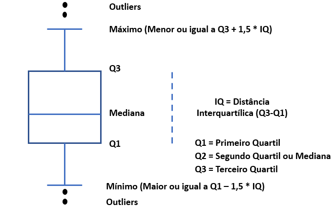

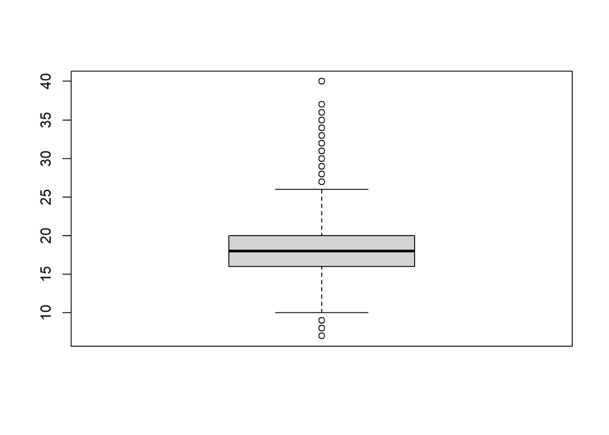

```r
boxplot(altura)
```

### 10.2.2 Histograma

Utilziamos histogramas para visualizar a distribuição de uma variável contínua. Em R o pacote “base” nos fornece a função `hist( )`.

**Exercício Prático**

- Mostrar o histograma para os dados da variável DAP disponível no vetor `dap`

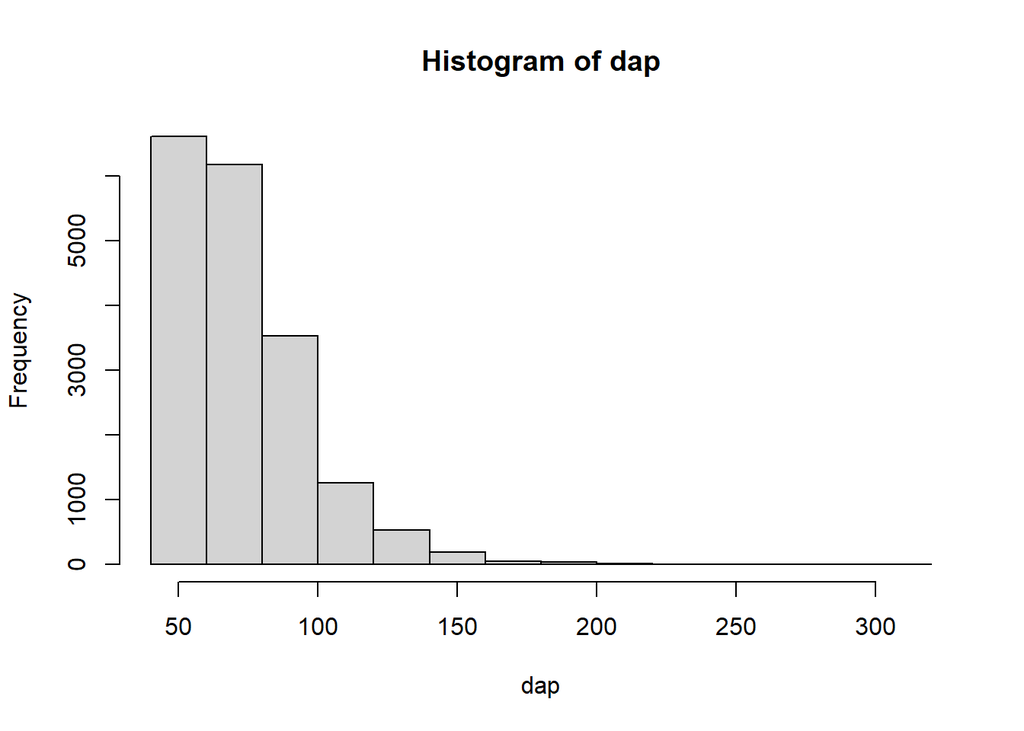

```r
hist(dap)
```

### 10.2.3 Gráfico Dispersão

O gráfico de dispersão é utilizado para visualizar a relação entre duas variáveis contínuas. Para gerar um gráfico de dispersão em R devemos utilizar a função `plot` do pacote “base”.

**Exercício Prático**

Visualizar a relação entre a varíavel altura e diâmetro.

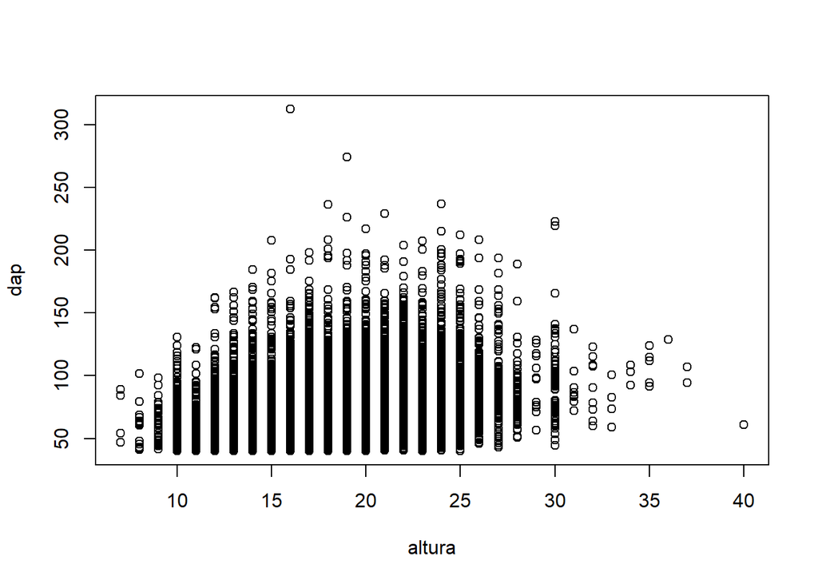

```r
plot(altura, dap)
```

## 10.3 Modificar a Aparência dos Gráficos

A configuração dos parâmetros de estilo, tamanho e agrupamento dos gráficos pode ser obtida digitando o comando ? par. Para este curso introdutório utilizaremos apenas o básico da configuração da aparecência de gráficos no pacote “base” do R.

### 10.3.1 Personalizando Histogramas

- `main` Utilizado para atribuir ou modificar um título do gráfico

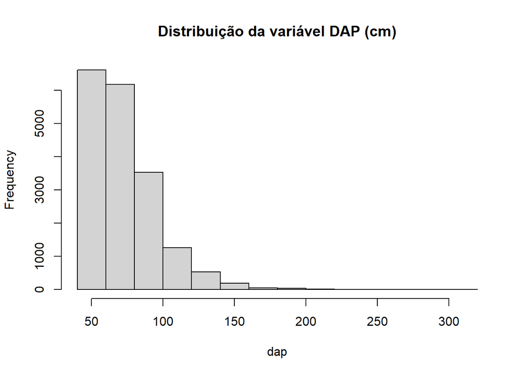

```r
# Modificar o título do gráfico
hist(dap, main = 'Distribuição da variável DAP (cm)')
```

- `xlab` e `ylab` - Modificar os nomes dos eixos x e y.

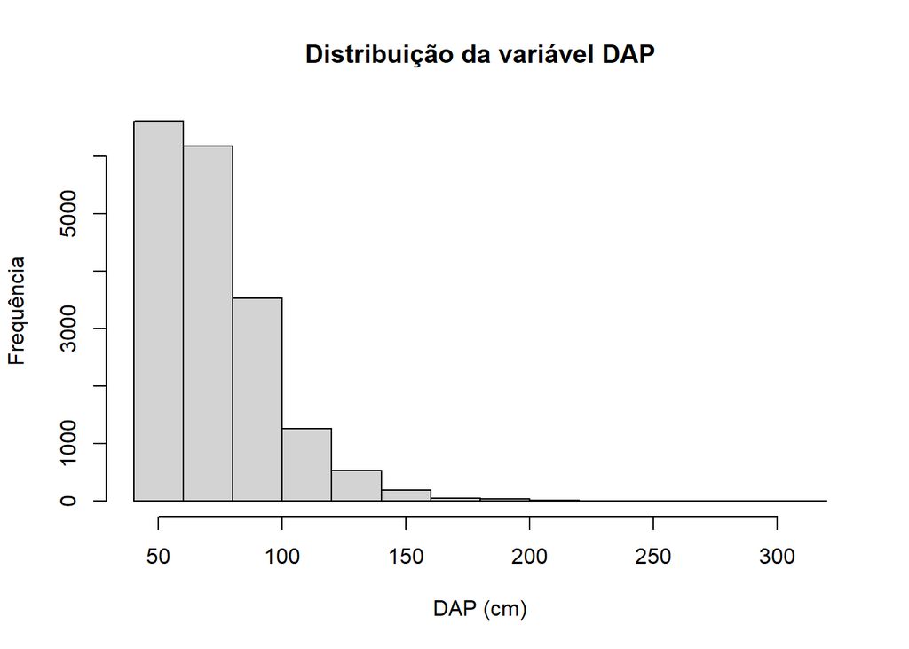

```r
# Modificar os rótulos dos eixos x e y
hist(dap,
     main = 'Distribuição da variável DAP', # título do gráfico
    xlab = 'DAP (cm)',   # Rótulo do eixo x
    ylab = 'Frequência') # Rótulo do eixo y
```

- `labels` - Mostra os valores de cada barra do histograma.

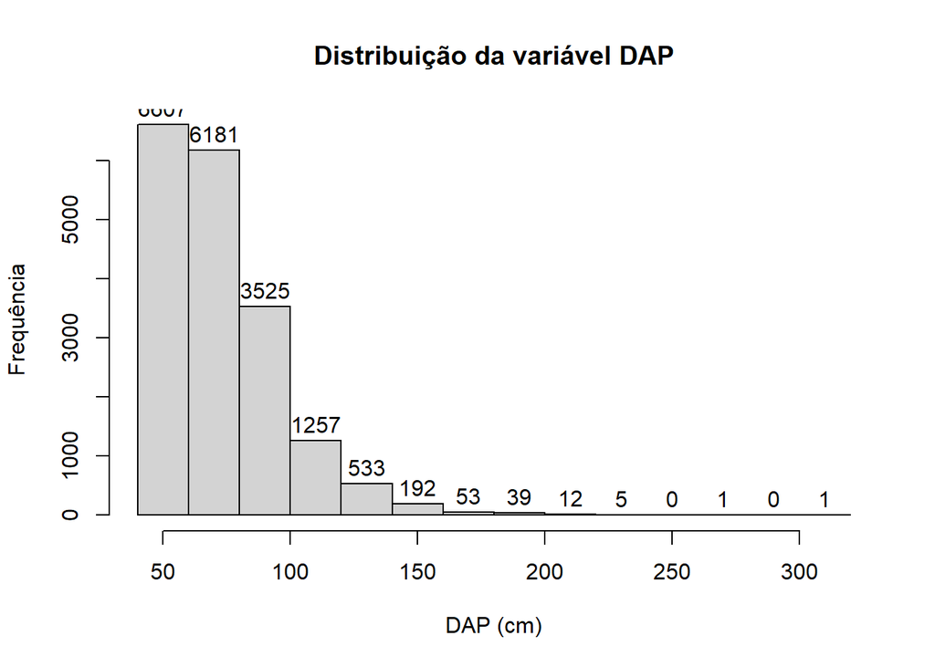

```r
hist(dap,
     main = 'Distribuição da variável DAP',
    xlab = 'DAP (cm)',
    ylab = 'Frequência',
    labels = TRUE)
```

- `col` - Muda a cor das barras do histograma.

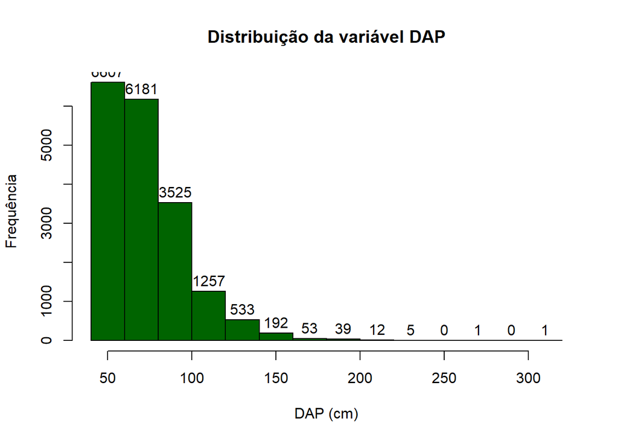

```r
hist(dap,
     main = 'Distribuição da variável DAP',
    xlab = 'DAP (cm)',
    ylab = 'Frequência',
    labels = TRUE,
    col = 'darkgreen')
```

- `density` e `angle` - Mostram as barras do histograma hachuradas

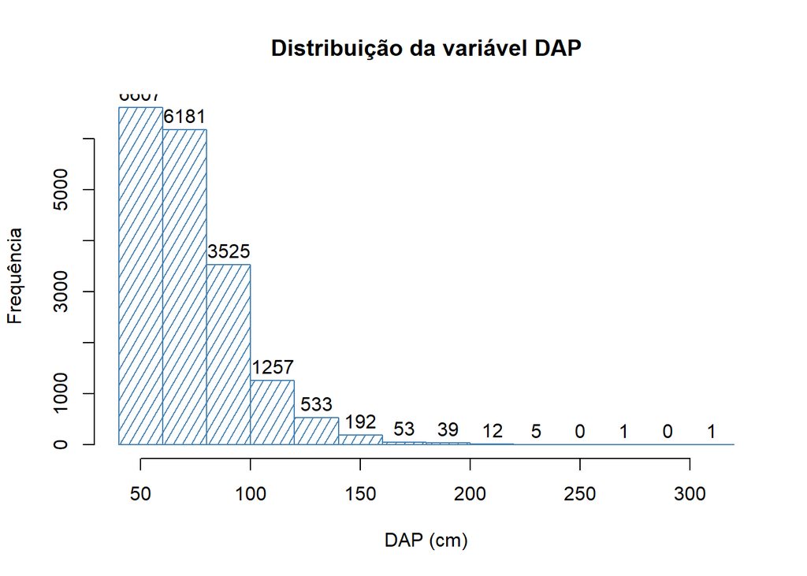

```r
hist(dap,
     main = 'Distribuição da variável DAP',
    xlab = 'DAP (cm)',
    ylab = 'Frequência',
    labels = TRUE,
    col = 'steelblue',
    density = 15,
    angle = 60)
```

- `Abline( )` - Função para adicionar uma linha reta ao histograma. Para adicionar uma linha vertical deve-se utilizar o argumento `v` e para linha horizontal `h`. O tipo de linha é modificado através do argumento `lty` (*line type*) e a espessura da linha através do argumento `lwd` (*line width*).

O exemplo a seguir mostra como adicionar uma linha ao histograma para representar a média dos diâmetros.

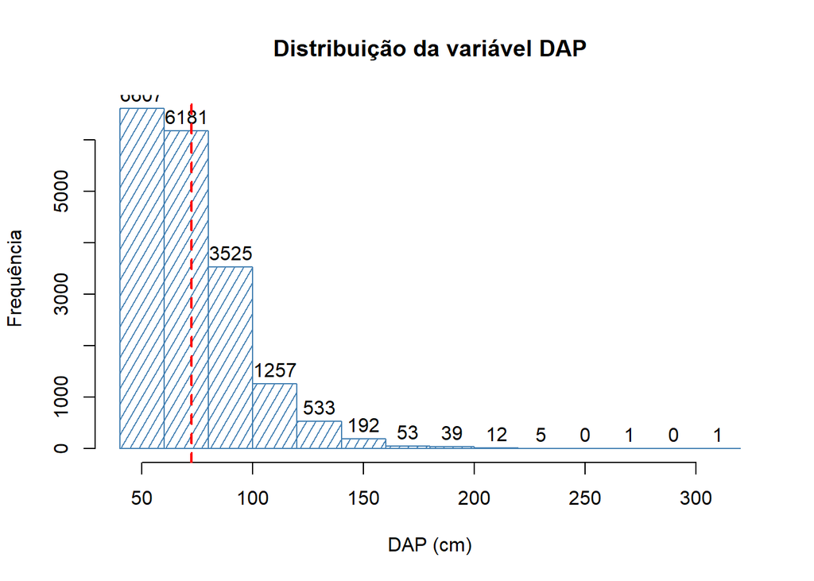

```r
hist(dap,
     main = 'Distribuição da variável DAP',
    xlab = 'DAP (cm)',
    ylab = 'Frequência',
    labels = TRUE,
    col = 'steelblue',
    density = 15,
    angle = 60)

abline(v = mean(dap),
       col = 'red',
       lty = 2,
       lwd = 2)
```

### 10.3.2 Personalizando Gráficos de Dispersão

- `pch` - Altera o tipo de caractere dos pontos

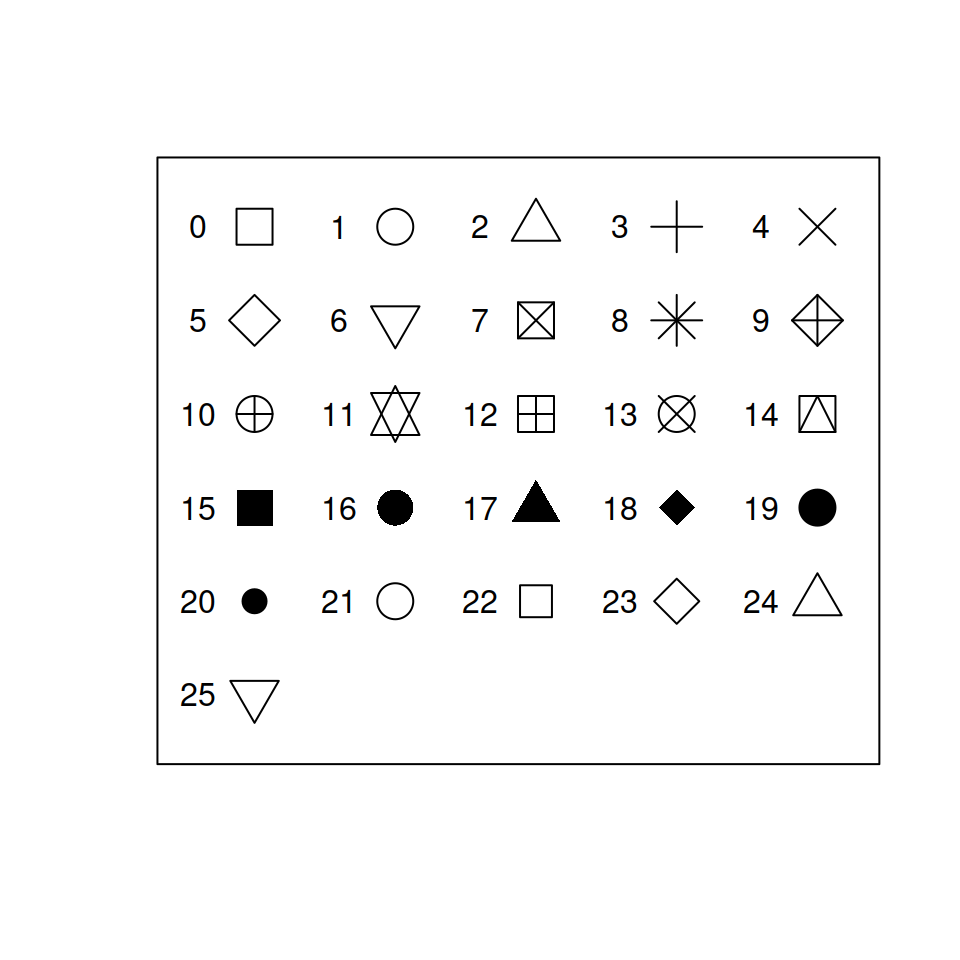

- Forma, Tamanho e Cor dos Pontos

| Argumento | Saída |
| --- | --- |
| `col` | Cor da borda do ponto. |
| `bg` | Cor do Fundo do ponto. |
| `cex` | Tamanho do ponto. |
| `lwd` | Espessura da Borda do Ponto. |

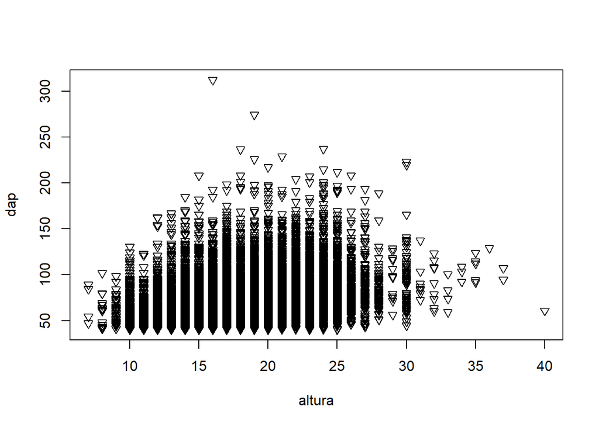

```r
# Alterar o tipo de caractere dos pontos
plot(altura, dap, pch = 25)
```

- `las` (*label style*) - Rotação dos rótulos dos eixos x e y.

| `las` | Rótulo |
| --- | --- |
| 0 | Paralelo aos eixos |
| 1 | Sempre na Horizontal |
| 2 | Sempre na Perpendicular |
| 3 | Sempre na Vertical |

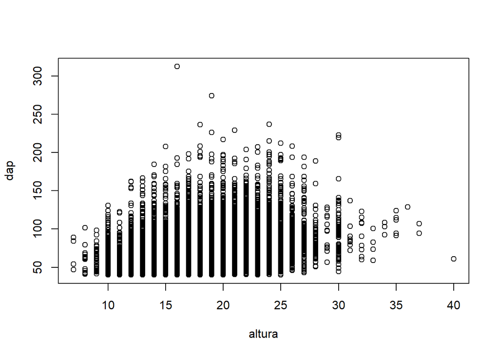

```r
plot(altura, dap, pch = 21, las = 0)
```

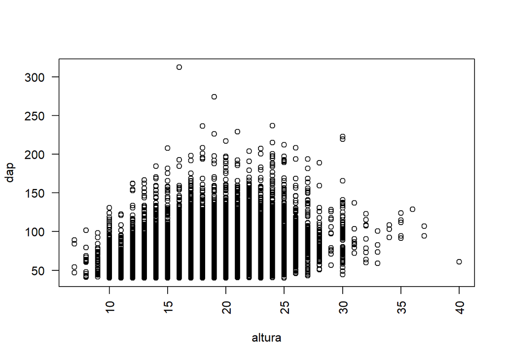

```r
plot(altura, dap, pch = 21, las = 2)
```

### 10.3.3 Agrupar Gráficos em uma Única Figura

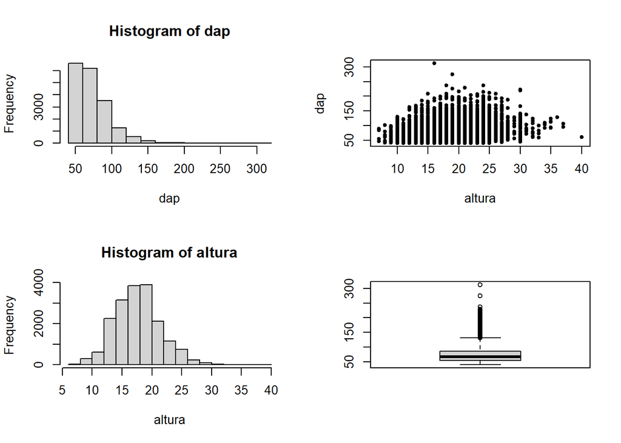

```r
# Parâmetros gráficos
par(mfcol = c(2, 2))

hist(dap, pin = c(12, 8))
hist(altura)
plot(altura, dap, pch = 20)
boxplot(dap)
```

# 11 Matriz

Matriz é uma estrutura de dados semelhante a vetor, exceto que na matriz temos 2 dimensões, uma para as linhas e outra para as colunas. O código a seguir mostra a criação de uma matriz 3x3.

```r
matriz <- matrix(1:9, nrow = 3, ncol = 3)
matriz
```

```
##      [,1] [,2] [,3]
## [1,]    1    4    7
## [2,]    2    5    8
## [3,]    3    6    9
```

## 11.1 Somar linhas e Colunas de uma Matriz

A função `apply`, parte do pacote `base` do R, pode ser usada para aplicar uma determinada função a uma matriz, e recebe 3 argumentos como parâmetro: a matriz contendo os dados, a indicação do sentido de aplicação da função, representado pelos números 1 (linha) ou 2 (coluna) e a função a ser aplicada.

Somar as linhas de uma matriz:

```r
print(apply(matriz, 1, sum))
```

```
## [1] 12 15 18
```

Somar os valores das colunas de uma matriz:

```r
print(apply(matriz, 2, sum))
```

```
## [1]  6 15 24
```

## 11.2 Somar os Elementos da Diagonal de uma Matriz

```r
m <- matrix(1:9, nrow = 3, ncol = 3)
print(m)
```

```
##      [,1] [,2] [,3]
## [1,]    1    4    7
## [2,]    2    5    8
## [3,]    3    6    9
```

```r
sum(diag(m))
```

```
## [1] 15
```

## 11.3 Sentido de Preenchimento dos Dados em uma Matriz

A função `matrix()` tem por padrão o preenchimento no sentido das colunas, porém, em alguns casos podemos necessitar preencher uma matriz no sentido das linhas, para isso devemos definir o valor do argumento `byrow = TRUE`

```r
matriz <- matrix(1:9, nrow = 3, ncol = 3, byrow = TRUE)
print(matriz)
```

```
##      [,1] [,2] [,3]
## [1,]    1    2    3
## [2,]    4    5    6
## [3,]    7    8    9
```

## 11.4 Atribuir Nomes as Linhas e Colunas de uma Matriz

```r
matriz <- matrix(1:9, nrow = 3, ncol = 3, byrow = TRUE)
print(matriz)
```

```
##      [,1] [,2] [,3]
## [1,]    1    2    3
## [2,]    4    5    6
## [3,]    7    8    9
```

```r
# Atribuir Nomes as Linhas da matriz
rownames(matriz) <- c('Linha 1', 'Linha 2', 'Linha 3')
```

```r
print(matriz)
```

```
##         [,1] [,2] [,3]
## Linha 1    1    2    3
## Linha 2    4    5    6
## Linha 3    7    8    9
```

```r
# Atribuir Nomes as colunas da matriz
colnames(matriz) <- c('Coluna 1', 'Coluna 2', 'Coluna 3')
```

```r
matriz
```

```
##         Coluna 1 Coluna 2 Coluna 3
## Linha 1        1        2        3
## Linha 2        4        5        6
## Linha 3        7        8        9
```

## 11.5 Obter os nomes das Linhas e Colunas de uma Matriz

**Somente os Nomes das Linhas**

```r
rownames(matriz)
```

```
## [1] "Linha 1" "Linha 2" "Linha 3"
```

**Somente os Nomes das Colunas**

```r
colnames(matriz)
```

```
## [1] "Coluna 1" "Coluna 2" "Coluna 3"
```

**Nomes das Linhas e Colunas**

```r
dimnames(matriz)
```

```
## [[1]]
## [1] "Linha 1" "Linha 2" "Linha 3"
##
## [[2]]
## [1] "Coluna 1" "Coluna 2" "Coluna 3"
```

## 11.6 Acessar Linhas e Colunas da Matriz

```r
# mostrar a primeira linha da matriz
print(matriz[1, ])
```

```
## Coluna 1 Coluna 2 Coluna 3
##        1        2        3
```

```r
# mostrar a segunda Coluna da matriz
print(matriz[, 2])
```

```
## Linha 1 Linha 2 Linha 3
##       2       5       8
```

## 11.7 Acessar Elementos da Matriz

```r
# Mostrar o elemento pertencente a segunda linha e segunda coluna
print(matriz[2, 2])
```

```
## [1] 5
```

## 11.8 Alterar os Elementos de uma Matriz

```r
# alterar o elemento da linha 2 coluna 2, número 5, para 0
matriz[2, 2] <- 0
print(matriz)
```

```
##         Coluna 1 Coluna 2 Coluna 3
## Linha 1        1        2        3
## Linha 2        4        0        6
## Linha 3        7        8        9
```

## 11.9 Operações com Matrizes

### 11.9.1 **Maior e menor valor entre os elementos da matriz**

```r
# maior valor entre os elementos da matriz
max(matriz)
```

```
## [1] 9
```

```r
# menor valor entre os elementos da matriz
min(matriz)
```

```
## [1] 0
```

### 11.9.2 **Maior e menor valor de uma linha ou coluna da matriz**

```r
# maior valor entre os elementos da primeira linha
max(matriz[1,])
```

```
## [1] 3
```

```r
# menor valor entre os elementos da terceira coluna
min(matriz[,3])
```

```
## [1] 3
```

### 11.9.3 **Média dos elementos da matriz**

```r
mean(matriz)
```

```
## [1] 4.444444
```

### 11.9.4 **Somar os valores das linhas e colunas**

### 11.9.5 **Soma de elementos da matriz**

```r
# somar os valores da primeira linha
sum(matriz[1, ])
```

```
## [1] 6
```

```r
# somar os valores da terceira coluna
sum(matriz[, 3])
```

```
## [1] 18
```

```r
# somar os elementos da segunda linha da matriz
sum(matriz[2, ])
```

```
## [1] 10
```

### 11.9.6 **Diagonal da matriz**

```r
# Obter a diagonal da matriz
print(diag(matriz))
```

```
## [1] 1 0 9
```

```r
# Obter a soma entre os elementos da diagonal da matriz
sum(diag(matriz))
```

```
## [1] 10
```

### 11.9.7 **Transposição de Matriz**

```r
# Transpor a matriz
t(matriz)
```

```
##          Linha 1 Linha 2 Linha 3
## Coluna 1       1       4       7
## Coluna 2       2       0       8
## Coluna 3       3       6       9
```

### 11.9.8 **Soma entre matrizes**

```r
# Definição das matrizes "a" e "b"
a <- matrix(1:6, nrow = 3, byrow = TRUE)
b <- matrix(1:6, nrow = 3, byrow = TRUE)

print(a)
```

```
##      [,1] [,2]
## [1,]    1    2
## [2,]    3    4
## [3,]    5    6
```

```r
print(b)
```

```
##      [,1] [,2]
## [1,]    1    2
## [2,]    3    4
## [3,]    5    6
```

```r
# soma das matrizes a e b
a + b
```

```
##      [,1] [,2]
## [1,]    2    4
## [2,]    6    8
## [3,]   10   12
```

## 11.10 Combinar Vetores em Matriz

Em R podemos combinar vetores para formar uma matriz em que cada vetor fará parte de uma coluna ou linha da matriz. Para combinar vetores em linhas matriciais usamos a função `rbind()`, e para combinar vetores em colunas da matriz usamos a função `cbind()`. O exemplo a seguir mostra como combinas três vetores com orientação nas linhas de uma matriz.

```r
# Vetor referente a uma amostra de valores de ações da Apple
apple <- c(109.49, 109.90, 109.11, 109.95, 111.03)

# Vetor referente a uma amostra de valores de ações da IBM
ibm <- c(159.82, 160.02, 159.84, 160.35, 164.79)

# Vetor referente a uma amostra de valores de ações da Microsoft
microsoft <- c(59.20, 59.25, 60.22, 59.95, 61.37)

# combinar os vetores em uma matriz onde cada linha receberá os valores dos vetores
print(rbind(apple, ibm, microsoft))
```

```
##             [,1]   [,2]   [,3]   [,4]   [,5]
## apple     109.49 109.90 109.11 109.95 111.03
## ibm       159.82 160.02 159.84 160.35 164.79
## microsoft  59.20  59.25  60.22  59.95  61.37
```

A seguir é demonstrado como combinar os elementos de vetores em colunas de uma matriz.

```r
# combinar os vetores em uma matriz onde cada coluna receberá os valores dos vetores
cbind(apple, ibm, microsoft)
```

```
##       apple    ibm microsoft
## [1,] 109.49 159.82     59.20
## [2,] 109.90 160.02     59.25
## [3,] 109.11 159.84     60.22
## [4,] 109.95 160.35     59.95
## [5,] 111.03 164.79     61.37
```

## 11.11 Matriz de Correlação

Como exemplo prático para demonstrar o uso de matriz para cálcular a correlação entre variáveis, usaremos os dados referente a publicação:

Ramsey, F.L. and Schafer, D.W. (2013). *The Statistical Sleuth*: A Course in Methods of Data Analysis (3rd ed), Cengage Learning.

Os dados são os valores médios de peso cerebral (g), peso corporal (g), duração da gestação (dias) e tamanho da prole de 96 espécies de mamíferos.

```r
# Carregar os dados vetoriais
load('./data/dados_modulo_1_aula_3.rda')

# listar os objetos no ambiente R
ls()
```

```
##  [1] "a"                 "altura"            "apple"
##  [4] "b"                 "categoria"         "cerebro"
##  [7] "corpo"             "dap"               "dias_semana"
## [10] "especies"          "gestacao"          "ibm"
## [13] "int"               "inteiros"          "letra"
## [16] "m"                 "matriz"            "microsoft"
## [19] "nomes"             "nomes_cientificos" "num"
## [22] "prole"             "sequencia"         "string"
## [25] "temperatura"       "vetor"
```

```r
# Combinar os vetores em uma matriz
m <- cbind(cerebro, corpo, gestacao, prole)

# Mostrar as primeiras 6 linhas da matriz
head(m)
```

```
##      cerebro   corpo gestacao prole
## [1,]     9.6    2.20       31   5.0
## [2,]     9.9    0.78       98   1.2
## [3,]  4480.0 2800.00      655   1.0
## [4,]    20.3    2.80      104   1.3
## [5,]   219.0   89.00      218   1.0
## [6,]    53.0    6.00       60   2.2
```

```r
# Mostrar as últimas 6 linhas da matriz
tail(m)
```

```
##       cerebro corpo gestacao prole
## [91,]     198  45.0      300   1.1
## [92,]     550 400.0      310   1.0
## [93,]     179  32.0      180   1.0
## [94,]     102   5.5      210   1.0
## [95,]     185 150.0      120   4.0
## [96,]     334 250.0      255   1.0
```

## 11.12 Atribuir um Atributo a uma Matriz

Para inserir um atributo a matriz utilizamos a função `attr()`, passando como argumentos a matriz e um rótulo para nomear o atributo. Como demonstração iremos inserir um atributo a nossa matriz definida anteriormente, este atributo será a referência bibliográfica dos dados.

```r
# Obter os atributos da matriz
attributes(m)
```

```
## $dim
## [1] 96  4
##
## $dimnames
## $dimnames[[1]]
## NULL
##
## $dimnames[[2]]
## [1] "cerebro"  "corpo"    "gestacao" "prole"
```

```r
# Inserir o atributo
attr(m, 'Fonte') <- 'Ramsey, F.L. and Schafer, D.W. (2013). The Statistical Sleuth: A Course in Methods of Data Analysis (3rd ed), Cengage Learning.'
```

```r
# conferir os atributos da matriz
attributes(m)
```

```
## $dim
## [1] 96  4
##
## $dimnames
## $dimnames[[1]]
## NULL
##
## $dimnames[[2]]
## [1] "cerebro"  "corpo"    "gestacao" "prole"
##
##
## $Fonte
## [1] "Ramsey, F.L. and Schafer, D.W. (2013). The Statistical Sleuth: A Course in Methods of Data Analysis (3rd ed), Cengage Learning."
```

## 11.13 Gerar Gráficos a partir dos Dados de uma Matriz

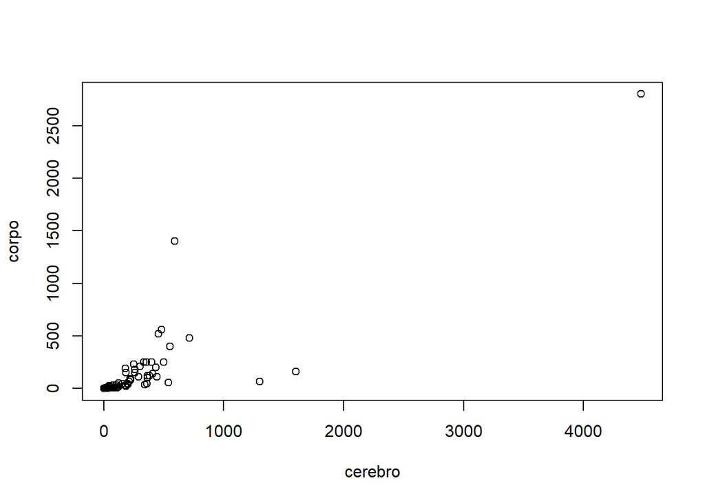

```r
# gráfico da relação entre as duas primeiras colunas (cerebro e corpo)
plot(m)
```

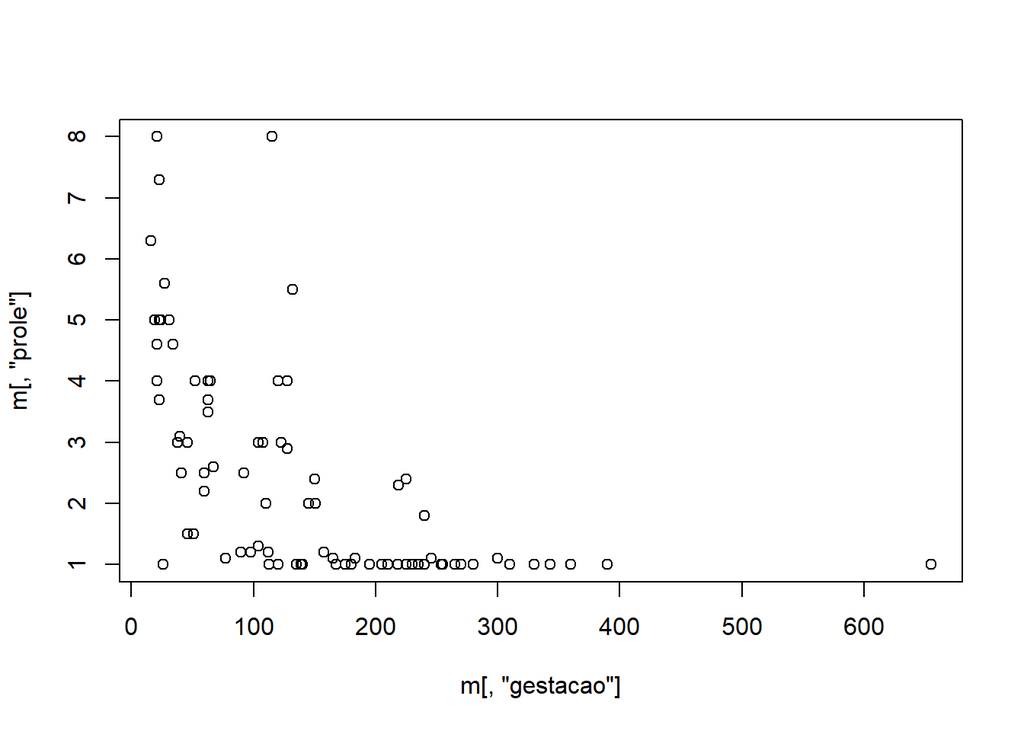

```r
# gráfico da relação entre as duas primeiras colunas (gestacao e prole)
# plot(m[, 3], m[, 4])
plot(m[,'gestacao'], m[,'prole'])
```

# 12 Array

Em R array é uma estrutura de dados tridimensional. Criamos um array através da função `array(x, dim)`, onde o parâmetros `x` é um vetor e `dim` são as dimensões do array.

```r
a <- array(c(1:24), dim = c(3, 3, 2))
```

```r
print(a)
```

```
## , , 1
##
##      [,1] [,2] [,3]
## [1,]    1    4    7
## [2,]    2    5    8
## [3,]    3    6    9
##
## , , 2
##
##      [,1] [,2] [,3]
## [1,]   10   13   16
## [2,]   11   14   17
## [3,]   12   15   18
```

## 12.1 Acessar Elementos do Array

```r
# Acessar a primeira tabela
a[, , 1]
```

```
##      [,1] [,2] [,3]
## [1,]    1    4    7
## [2,]    2    5    8
## [3,]    3    6    9
```

```r
# Acessar a primeira linha da tabela 1
print(a[1, , 1])
```

```
## [1] 1 4 7
```

```r
# Acessar a primeira coluna da segunda tabela
print(a[, 1, 2])
```

```
## [1] 10 11 12
```

## 12.2 Operações com Arrays

```r
# Obter o maior valor da primeira tabela
max(a[, , 1])
```

```
## [1] 9
```

```r
# Obter a soma da primeira coluna da tabela 1
sum(a[, 1, 1])
```

```
## [1] 6
```

```r
# obter a média dos valores da segunda linha da segunda tabela
mean(a[, 2, 2])
```

```
## [1] 14
```

```r
# Obter a soma entre os valores da primeira coluna da table 1 com os da
# primeira coluna da tabela 2
sum(a[, 1, 1], a[, 1, 2])
```

```
## [1] 39
```

```r
# obter a soma dos valores da diagonal da primeira tabele
sum(diag(a[, , 1]))
```

```
## [1] 15
```

## 12.3 Atribuir Nomes as Dimensões do Array

Assim como podemos atribuir nomes aos elementos de um vetor e as duas dimensões de uma matriz, também é possível o fazer para arrays. Para tal utilizamos a função `dimnames()`, passando como parâmetros três vetores com os nomes das linhas da matriz, nomes das colunas e nomes das matrizes.

```r
a <- array(c(1:24),  # Vetor
           dim = c(3, 3, 2),  # Dimensões do array
           dimnames = list(c('L1', 'L2', 'L3'),  # Nome das linhas das matrizes
                           c('C1', 'C2', 'C3'),  # Nome das colunas das matrizes
                           c('Matriz 1', 'Matriz 2')))  # Nomes das Matrizes

print(a)
```

```
## , , Matriz 1
##
##    C1 C2 C3
## L1  1  4  7
## L2  2  5  8
## L3  3  6  9
##
## , , Matriz 2
##
##    C1 C2 C3
## L1 10 13 16
## L2 11 14 17
## L3 12 15 18
```

## 12.4 Inserir Atributo em um Array

```r
# inserir um atributo ao array "a"
attr(a, 'Observação') <- 'Meu primeiro array em R!!'
```

```r
# checar os atributos do array
print(attributes(a))
```

```
## $dim
## [1] 3 3 2
##
## $dimnames
## $dimnames[[1]]
## [1] "L1" "L2" "L3"
##
## $dimnames[[2]]
## [1] "C1" "C2" "C3"
##
## $dimnames[[3]]
## [1] "Matriz 1" "Matriz 2"
##
##
## $Observação
## [1] "Meu primeiro array em R!!"
```

# 13 Data Frames

*dataframe* indiscutivelmente é a estrutura de dados mais importante em R, é nesta estrutura que a maioria dos seus dados será armazenada para análise. Combina a estrutura de uma matriz com a flexibilidade de ter diferentes tipos de dados em cada coluna. Pense em cada coluna como um vetor armazendo um tipo de dado específico. Para criar um *dataframe* utilizamos a função dataframe( ).

## 13.1 Criar um data frame

```r
# criar um data frame
df <- data.frame(
    # Coluna id
    id = c(1, 2, 3, 4, 5),
    # Coluna nome
    nome = c('Mezilaurus itauba', 'Apuleia leiocarpa', 'Cedrela odorata',
             'Amburana acreana', 'Hymenolobium excelsum'),
    # Coluna volume
    volume = c(3.25, 6.51, 7.45, 8.81, 4.35)
)

# mostrar os dados na tela
df
```

```
##   id                  nome volume
## 1  1     Mezilaurus itauba   3.25
## 2  2     Apuleia leiocarpa   6.51
## 3  3       Cedrela odorata   7.45
## 4  4      Amburana acreana   8.81
## 5  5 Hymenolobium excelsum   4.35
```

## 13.2 Carregar um data frame a partir de um arquivo

Em R é possível a leitura de vários formatos de arquivos utilizados para armazenamento de dados, a exemplo de:

- **.csv**
- `.dbf`
- `.dta` (Stata)
- `.fst`
- `.h5`
- `.mtp` (Minitab)
- `.parquet`
- **.rda**
- **.rds**
- **.RData**
- `.spss` (SPSS)
- **.txt**
- `.xls` e `.xlsx`
- `.xml`
- `.xport` (SAS)

Abordaremos neste módulo apenas os formatos mais frequentemente utilizados, a saber: `.csv`, `.txt`, `.rds` e `.xls`

Para leitura de arquivos nos formatos .csv e .txt, podemos utilizar a função read.csv( ) ou read.csv2( ), a primeira por padrão lê dados de planilhas onde o separador decimal é o . e o separador de colunas é a ,; ao passo que a segunda função é utilizada para leitura de planilhas onde o separador decimal é a , e o separdor de colunas é o ;

## 13.3 Leitura de Arquivos .csv e .txt

O trecho de código a seguir faz a leitura de uma planilha em formato .csv, a qual é atribuída ao objeto R denominado inventario, o qual após leitura dos dados passa a ser um dataframe, pois as colunas da planilha são importadas como vetores. Assim, podemos definir dataframe como um conjunto de vetores, mas pode também armazenar listas.

```r
# Lê uma planilha csv com dados de inventário florestal
inventario <- read.csv2('./data/UMF_4_UPA_4F_SINAFLOR_v03.csv',
                encoding = 'latin1')
```

A seguir usamos a função head( ) para mostrar as linhas iniciais do dataframeinventario. Por padrão esta função mostra apenas as seis primeiras linhas do dataframe, caso queiramos ler as dez primeiras linhas, devemos especificar este número após o nome do dataframe: head(inventario, 10)

```r
# Mostrar as seis primeiras linhas dos dados no console
head(inventario)
```

```
##   N_arv UPA UT     Nome_Cientifico Nome_Popular DAP_cm Alt    Categoria QF
## 1 10001   6  1 Parkia gigantocarpa   Fava-atanã 114.59  19 Remanescente  1
## 2 10002   6  1  Bagassa guianensis     Tatajuba  67.48  17 Remanescente  1
## 3 10003   6  1       Castilla ulei       Caucho  52.52  11     Explorar  1
## 4 10004   6  1       Castilla ulei       Caucho  40.74  13 Remanescente  1
## 5 10005   6  1     Vochysia maxima      Quaruba  47.75  15 Remanescente  2
## 6 10006   6  1    Copaifera duckei      Copaíba  43.93  18 Remanescente  1
##       Vol      g       lat       lon
## 1 12.4891 1.0313 -5.907904 -54.96910
## 2  4.3893 0.3577 -5.907938 -54.96912
## 3  1.8263 0.2166 -5.907999 -54.96991
## 4  1.1068 0.1304 -5.906353 -54.96999
## 5  1.8325 0.1790 -5.906086 -54.97024
## 6  1.7038 0.1515 -5.905871 -54.97024
```

A seguir usamos a função tail( ) para mostrar as últimas linhas do dataframeinventario. Por padrão esta função mostra apenas as seis últimas linhas do dataframe, caso queiramos ler as dez últimas linhas, devemos especificar este número após o nome do dataframe: tail(inventario, 10)

```r
# Mostrar as seis últimas linhas dos dados no console
tail(inventario)
```

```
##        N_arv UPA UT      Nome_Cientifico Nome_Popular DAP_cm Alt    Categoria
## 18583 290695   6 29     Parkia multijuga  Fava-benguê  52.52  15 Remanescente
## 18584 290696   6 29 Couratari guianensis       Tauari  92.95  24     Explorar
## 18585 290697   6 29      Vochysia maxima      Quaruba 112.68  20 Remanescente
## 18586 290698   6 29  Hymenaea parvifolia  Jutaí-mirim  66.53  18 Remanescente
## 18587 290699   6 29      Vochysia maxima      Quaruba 127.32  19     Explorar
## 18588 290700   6 29      Vochysia maxima      Quaruba  54.75  17 Remanescente
##       QF     Vol      g       lat       lon
## 18583  2  2.3001 0.2166 -5.853998 -54.97232
## 18584  1 10.4347 0.6785 -5.853668 -54.97245
## 18585  2 12.6251 0.9972 -5.853556 -54.97230
## 18586  2  4.4416 0.3476 -5.853985 -54.96238
## 18587  1 14.6343 1.2732 -5.854445 -54.96315
## 18588  2  2.7760 0.2354 -5.854735 -54.96475
```

## 13.4 Obter os nomes das colunas de um Dataframe

Alguns Dataframes contém um número muito grande de colunas e precisamos atribuir os mesmos nomes a outros dataframes que formos criando, para evitar ter que digitar estes nomes outras vezes, podemos usar as função names( ) e attributes( ).

A primeira retornará um saída vetorial ao passo que a segunda uma lista com três elementos, o primeiro é names: nomes das colunas; class: mostra a estrutura de dados, no caso data.frame; row.names: referente ao nomes dos rótulos das linhas, se houver. Para acessarmos somente os nomes das colunas usando a função attributes() devemos chamá-la da seguinte forma: attributes(dataframe)[1]

```r
# Mostrar os nomes das colunas do data frame
names(inventario)
```

```
##  [1] "N_arv"           "UPA"             "UT"              "Nome_Cientifico"
##  [5] "Nome_Popular"    "DAP_cm"          "Alt"             "Categoria"
##  [9] "QF"              "Vol"             "g"               "lat"
## [13] "lon"
```

```r
# Mostrar todos os attributos do data frame, menos os rótulos das lihas
attributes(inventario)[-3]
```

```
## $names
##  [1] "N_arv"           "UPA"             "UT"              "Nome_Cientifico"
##  [5] "Nome_Popular"    "DAP_cm"          "Alt"             "Categoria"
##  [9] "QF"              "Vol"             "g"               "lat"
## [13] "lon"
##
## $class
## [1] "data.frame"
```

```r
# Mostrar apenas o primeiro atributo (nomes das colunas)
attributes(inventario)[1]
```

```
## $names
##  [1] "N_arv"           "UPA"             "UT"              "Nome_Cientifico"
##  [5] "Nome_Popular"    "DAP_cm"          "Alt"             "Categoria"
##  [9] "QF"              "Vol"             "g"               "lat"
## [13] "lon"
```

## 13.5 Obter número de linhas e colunas de uma Dataframe

A função dim( ) recebe como parâmetro um dataframe e retorna o número de linhas e colunas.

```r
# Mostrar as dimensões do data frame
dim(inventario)
```

```
## [1] 18588    13
```

- Podemos acessar apenas o número de linhas ou de colunas: `dim(inventario)[1]` e `dim(inventario)[2]`, respetivamente.

```r
# Mostrar apenas o número de linhas do dataframe
dim(inventario)[1]
```

```
## [1] 18588
```

```r
# Mostrar apenas o número de colunas do dataframe
dim(inventario)[2]
```

```
## [1] 13
```

Os comandos acima podem ser simplificados com o uso apenas das funções `nrow()` e `ncol()`. veja os exemplos a seguir:

```r
# Obter o número de linhas de um dataframe
nrow(inventario)
```

```
## [1] 18588
```

```r
# Obter o número de colunas de um dataframe
ncol(inventario)
```

```
## [1] 13
```

Dos exemplos acima podemos observar que foram inventariadas 18.588 árvores (número de linhas) e que o dataframe contém 13 variáveis (colunas)

## 13.6 Obter a Estrutura dos Dados de um DataFrame

```r
# Verificar a estrutura dos dados
str(inventario)
```

```
## 'data.frame':    18588 obs. of  13 variables:
##  $ N_arv          : int  10001 10002 10003 10004 10005 10006 10007 10008 10009 10010 ...
##  $ UPA            : int  6 6 6 6 6 6 6 6 6 6 ...
##  $ UT             : int  1 1 1 1 1 1 1 1 1 1 ...
##  $ Nome_Cientifico: chr  "Parkia gigantocarpa" "Bagassa guianensis" "Castilla ulei" "Castilla ulei" ...
##  $ Nome_Popular   : chr  "Fava-atanã" "Tatajuba" "Caucho" "Caucho" ...
##  $ DAP_cm         : num  114.6 67.5 52.5 40.7 47.8 ...
##  $ Alt            : int  19 17 11 13 15 18 16 20 20 15 ...
##  $ Categoria      : chr  "Remanescente" "Remanescente" "Explorar" "Remanescente" ...
##  $ QF             : int  1 1 1 1 2 1 2 1 1 1 ...
##  $ Vol            : num  12.49 4.39 1.83 1.11 1.83 ...
##  $ g              : num  1.031 0.358 0.217 0.13 0.179 ...
##  $ lat            : num  -5.91 -5.91 -5.91 -5.91 -5.91 ...
##  $ lon            : num  -55 -55 -55 -55 -55 ...
```

## 13.7 Resumo dos Dados de um Dataframe

```r
# Mostrar o resumo dos dados
summary(inventario)
```

```
##      N_arv             UPA          UT        Nome_Cientifico
##  Min.   : 10001   Min.   :6   Min.   : 1.00   Length:18588
##  1st Qu.: 90010   1st Qu.:6   1st Qu.: 9.00   Class :character
##  Median :160623   Median :6   Median :16.00   Mode  :character
##  Mean   :161674   Mean   :6   Mean   :16.13
##  3rd Qu.:240164   3rd Qu.:6   3rd Qu.:24.00
##  Max.   :290700   Max.   :6   Max.   :29.00
##  Nome_Popular           DAP_cm            Alt         Categoria
##  Length:18588       Min.   : 39.79   Min.   : 7.00   Length:18588
##  Class :character   1st Qu.: 54.11   1st Qu.:16.00   Class :character
##  Mode  :character   Median : 66.85   Median :18.00   Mode  :character
##                     Mean   : 71.95   Mean   :18.12
##                     3rd Qu.: 84.99   3rd Qu.:20.00
##                     Max.   :312.26   Max.   :40.00
##        QF             Vol                g               lat
##  Min.   :1.000   Min.   : 0.7213   Min.   :0.1243   Min.   :-5.918
##  1st Qu.:1.000   1st Qu.: 2.7023   1st Qu.:0.2300   1st Qu.:-5.897
##  Median :1.000   Median : 4.4863   Median :0.3509   Median :-5.881
##  Mean   :1.282   Mean   : 5.5925   Mean   :0.4523   Mean   :-5.883
##  3rd Qu.:2.000   3rd Qu.: 7.3581   3rd Qu.:0.5673   3rd Qu.:-5.871
##  Max.   :3.000   Max.   :39.0858   Max.   :7.6582   Max.   :-5.848
##       lon
##  Min.   :-55.00
##  1st Qu.:-54.97
##  Median :-54.96
##  Mean   :-54.96
##  3rd Qu.:-54.95
##  Max.   :-54.94
```

## 13.8 Acessar colunas do data frame

Para acessar uma coluna específica de um data frame usamos o sinal `$`, se queremos acessar somente a coluna referente a variável volume, denominada em nossa data frame de `Vol`: `inventario$Vol`. Isso nos permite aplicar uma função apenas a esta coluna:

```r
# Selecionar a coluna "Vol" e Mostrar o resumo dos dados da coluna "Vol"
summary(inventario$Vol)
```

```
##    Min. 1st Qu.  Median    Mean 3rd Qu.    Max.
##  0.7213  2.7023  4.4863  5.5925  7.3581 39.0858
```

## 13.9 Filtrar Linhas e/ou Colunas de uma Data Frame

Em função do data frame possuir duas dimensões, é possível localizar uma lina e/ou uma coluna através das coordenadas de suas dimensões. Vamos considerar como exemplo os dados referente a lista de espécies da fauna brasileira ameaçadas de extinção.

```r
fauna <- read.csv2('./data/DF_port_MMA_300-2022_fauna.csv')

head(fauna)
```

```
##   n port443 classe           ordem      familia       especie_subespecie
## 1 1       *   Aves Accipitriformes Accipitridae Amadonastur lacernulatus
## 2 2       *   Aves Accipitriformes Accipitridae          Circus cinereus
## 3 3       *   Aves Accipitriformes Accipitridae           Harpia harpyja
## 4 4       *   Aves Accipitriformes Accipitridae         Leptodon forbesi
## 5 5       *   Aves Accipitriformes Accipitridae      Morphnus guianensis
## 6 6       *   Aves Accipitriformes Accipitridae      Urubitinga coronata
##   categoria
## 1        VU
## 2        VU
## 3        VU
## 4        EN
## 5        VU
## 6        EN
```

Para filtrar a segunda linha passamos o endereço desta linha no data frame

```r
fauna[2, ]
```

```
##   n port443 classe           ordem      familia especie_subespecie categoria
## 2 2       *   Aves Accipitriformes Accipitridae    Circus cinereus        VU
```

Para filtrar apenas a terceira coluna

```r
fauna[, 3]
```

```
##    [1] "Aves"           "Aves"           "Aves"           "Aves"
##    [5] "Aves"           "Aves"           "Anthozoa"       "Arachnida"
##    [9] "Arachnida"      "Arachnida"      "Arachnida"      "Arachnida"
##   [13] "Arachnida"      "Arachnida"      "Arachnida"      "Arachnida"
##   [17] "Malacostraca"   "Malacostraca"   "Malacostraca"   "Malacostraca"
##   [21] "Malacostraca"   "Malacostraca"   "Malacostraca"   "Malacostraca"
##   [25] "Malacostraca"   "Malacostraca"   "Malacostraca"   "Malacostraca"
##   [29] "Malacostraca"   "Malacostraca"   "Aves"           "Hydrozoa"
##   [33] "Amphibia"       "Amphibia"       "Diplopoda"      "Diplopoda"
##   [37] "Amphibia"       "Amphibia"       "Amphibia"       "Amphibia"
##   [41] "Amphibia"       "Amphibia"       "Amphibia"       "Amphibia"
##   [45] "Amphibia"       "Amphibia"       "Amphibia"       "Amphibia"
##   [49] "Amphibia"       "Amphibia"       "Amphibia"       "Amphibia"
##   [53] "Amphibia"       "Amphibia"       "Amphibia"       "Amphibia"
##   [57] "Amphibia"       "Amphibia"       "Amphibia"       "Amphibia"
```

[output cut: 302 more lines]

Também podemos filtrar um data frame com base em uma coluna

```r
fauna[fauna$especie_subespecie == 'Euvola ziczac', ]
```

```
##       n port443   classe     ordem    familia especie_subespecie categoria
## 672 679       * Bivalvia Ostreoida Pectinidae      Euvola ziczac        EN
```

## 13.10 Filtrar dados com a função `subset`

```r
# Gerar um subconjunto das árvores selecionadas para corte
especies_explorar <- subset(inventario, Categoria == 'Explorar')

# Mostrar o subconjunto
head(especies_explorar)
```

```
##    N_arv UPA UT               Nome_Cientifico  Nome_Popular DAP_cm Alt
## 3  10003   6  1                 Castilla ulei        Caucho  52.52  11
## 7  10007   6  1 Pseudopiptadenia psilostachya     Timborana  59.52  16
## 9  10009   6  1         Hymenolobium petraeum Angelim-pedra  72.57  20
## 13 10013   6  1                 Goupia glabra       Cupiúba  74.80  16
## 23 10023   6  1               Manilkara elata   Maçaranduba  74.17  19
## 24 10024   6  1                 Goupia glabra       Cupiúba  63.66  14
##    Categoria QF    Vol      g       lat       lon
## 3   Explorar  1 1.8263 0.2166 -5.907999 -54.96991
## 7   Explorar  2 3.2062 0.2783 -5.905860 -54.97020
## 9   Explorar  1 5.7342 0.4137 -5.905200 -54.97010
## 13  Explorar  2 5.1779 0.4395 -5.903429 -54.97043
## 23  Explorar  1 5.7705 0.4320 -5.906069 -54.97048
## 24  Explorar  1 3.3641 0.3183 -5.906245 -54.97040
```

```r
# Número de Árvores a Explorar
nrow(especies_explorar)
```

```
## [1] 8221
```

```r
# ler os dados da portaria MMA 300/2022
port_300_flora <- read.csv2('./data/DF_port_MMA_300-2022_flora.csv')

# Mostrar na tela apenas 6 linhas do data frame
head(port_300_flora)
```

```
##   n port443     familia        especie_subespecie_var categoria
## 1 1       * Acanthaceae Aphelandra espirito-santensis        EN
## 2 2       * Acanthaceae         Aphelandra margaritae        VU
## 3 3       * Acanthaceae        Aphelandra maximiliana        EN
## 4 4         Acanthaceae             Aphelandra rigida        EN
## 5 5         Acanthaceae      Aphelandra stephanophysa        VU
## 6 6       * Acanthaceae      Dyschoriste lavandulacea        EN
```

```r
# Filtar as espécies do inventario que coincidem as espécies da Portaria
# MMA 300/2022 e atribuir a categoria de ameaça a uma nova coluna em inventario,
# a ser denominada status_ecologico.
inventario_ameacadas <- inventario[inventario$Nome_Cientifico %in% port_300_flora$especie_subespecie_var, ]
```

Agora podemos saber quais espécies do inventário florestal são ameaçadas de extinção:

```r
unique(inventario_ameacadas$Nome_Cientifico)
```

```
## [1] "Bertholletia excelsa" "Apuleia leiocarpa"    "Cedrela odorata"
## [4] "Hymenaea parvifolia"  "Virola surinamensis"  "Mezilaurus itauba"
```

## 13.12 Excluir Linhas e Colunas de um Data Frame

```r
# Excluir a linha 2
fauna <- fauna[-2, ]

# Conferir a remoção da linha 2
head(fauna)
```

```
##   n port443   classe           ordem      familia       especie_subespecie
## 1 1       *     Aves Accipitriformes Accipitridae Amadonastur lacernulatus
## 3 3       *     Aves Accipitriformes Accipitridae           Harpia harpyja
## 4 4       *     Aves Accipitriformes Accipitridae         Leptodon forbesi
## 5 5       *     Aves Accipitriformes Accipitridae      Morphnus guianensis
## 6 6       *     Aves Accipitriformes Accipitridae      Urubitinga coronata
## 7 7       * Anthozoa      Actiniaria   Actiniidae     Condylactis gigantea
##   categoria
## 1        VU
## 3        VU
## 4        EN
## 5        VU
## 6        EN
## 7        EN
```

```r
# Excluir a coluna n
fauna$n <- NULL

# Conferir a remoção da coluna 1
head(fauna)
```

```
##   port443   classe           ordem      familia       especie_subespecie
## 1       *     Aves Accipitriformes Accipitridae Amadonastur lacernulatus
## 3       *     Aves Accipitriformes Accipitridae           Harpia harpyja
## 4       *     Aves Accipitriformes Accipitridae         Leptodon forbesi
## 5       *     Aves Accipitriformes Accipitridae      Morphnus guianensis
## 6       *     Aves Accipitriformes Accipitridae      Urubitinga coronata
## 7       * Anthozoa      Actiniaria   Actiniidae     Condylactis gigantea
##   categoria
## 1        VU
## 3        VU
## 4        EN
## 5        VU
## 6        EN
## 7        EN
```

## 13.13 Ler Dados de Arquivo Demilitado por Tabulação

```r
dados <- read.delim2('./data/Bivalvia_tab.txt')
head(dados)
```

```
##      n port443   classe     ordem       familia especie_subespecie categoria
## 1  679       * Bivalvia Ostreoida    Pectinidae      Euvola ziczac        EN
## 2 1275       * Bivalvia Unionoida      Hyriidae Diplodon koseritzi        EN
## 3 1276       * Bivalvia Unionoida Mycetopodidae Mycetopoda legumen        EN
```

## 13.14 Ler Dados de Arquivo Delimitado por Espaço

```r
dados <- read.delim2('./data/Separado_por_Espaco.txt', sep = ' ')

head(dados)
```

```
##   id                  nome volume
## 1  1     Mezilaurus itauba   3.25
## 2  2     Apuleia leiocarpa   6.51
## 3  3       Cedrela odorata   7.45
## 4  4      Amburana acreana   8.81
## 5  5 Hymenolobium excelsum   4.35
```

## 13.15 Ler Dados de Arquivo Hospedado na Internet

A seguir é mostrado como ler dados diretamente da internet, como exemplo iremos ler um conjunto de dados do SISTAXON.

```r
# Link da planilha com dados do Sistaxon
link <- 'http://www.ibama.gov.br/phocadownload/sinaflor/2022/2022-07-22_Lista_especies_DOF.csv'

# Ler o arquivo csv diretamente do link
#sp_sistaxon <- read.csv(link)

# Mostrar os dados no sonsole
#head(sp_sistaxon)
```

## 13.16 Leitura de Dados em Formatos de Aqruivos de Softwares Proprietários

| Arquivo | Pacote | Função |
| --- | --- | --- |
| .dbf | foreign | read.dbf( ) |
| .dta | foreign | read.tda( ) |
| .fst | fst | read_fst( ) |
| .mtp | foreign | read.mtp( ) |
| .spss | foreign | read.spss( ) |
| .xls |  | read_xls( ) |
| .xls |  | read_xlsx( ) |
| .xport | foreign | read.xport( ) |

## 13.17 Ler Dados de Arquivos .xls e .xlsx

```r
# Carregar o pacote readxl
library(readxl)

# Listar as planilhas presentes no arquivo .xls
xls <- excel_sheets('./data/aves_reptilia.xls')
xls
```

```
## [1] "aves"     "reptilia"
```

Por padrão a função `read_xls()` lê a primeira planilha do arquivo.

```r
# Ler dados da primeira planilha "aves" e atribuir a um dataframe
dados_fauna <- read_xls('./data/aves_reptilia.xls')

# Mostrar as primeiras seis linhas do dataframe
head(dados_fauna)
```

```
## # A tibble: 6 × 7
##       n port443 classe ordem           familia      especie_subespecie categoria
##   <dbl> <chr>   <chr>  <chr>           <chr>        <chr>              <chr>
## 1     1 *       Aves   Accipitriformes Accipitridae Amadonastur lacer… VU
## 2     2 *       Aves   Accipitriformes Accipitridae Circus cinereus    VU
## 3     3 *       Aves   Accipitriformes Accipitridae Harpia harpyja     VU
## 4     4 *       Aves   Accipitriformes Accipitridae Leptodon forbesi   EN
## 5     5 *       Aves   Accipitriformes Accipitridae Morphnus guianens… VU
## 6     6 *       Aves   Accipitriformes Accipitridae Urubitinga corona… EN
```

Para ler uma outra planilha devemos passar essa informação para o parâmetro `sheets`. Se quisermos ler a planilha `reptilia` o código seria: `read_xls('./data/aves_reptilia.xls', sheet = 'reptilia')` ou `read_xls('./data/aves_reptilia.xls', sheet = 2)`

```r
# Ler dados da primeira planilha "reptilia" e atribuir a um dataframe
dados_fauna <- read_xls('./data/aves_reptilia.xls', sheet = 'reptilia')

# Mostrar as primeiras seis linhas do dataframe
head(dados_fauna)
```

```
## # A tibble: 6 × 7
##       n port443 classe   ordem    familia        especie_subespecie    categoria
##   <dbl> <chr>   <chr>    <chr>    <chr>          <chr>                 <chr>
## 1  1168 *       Reptilia Squamata Amphisbaenidae Amphisbaena arda      EN
## 2  1169 *       Reptilia Squamata Amphisbaenidae Amphisbaena frontalis EN
## 3  1170 *       Reptilia Squamata Amphisbaenidae Amphisbaena nigricau… EN
## 4  1171 *       Reptilia Squamata Amphisbaenidae Amphisbaena supernum… EN
## 5  1172 *       Reptilia Squamata Amphisbaenidae Amphisbaena uroxena   EN
## 6  1173 *       Reptilia Squamata Amphisbaenidae Leposternon kisteuma… VU
```

# 14 Salvar Data Frame

## 14.1 .csv

```r
# criar um data frame
df <- data.frame(
    # Definir a coluna id
    id = c(1, 2, 3, 4, 5),
    # Definir a coluna nome
    nome = c('Mezilaurus itauba', 'Apuleia leiocarpa', 'Cedrela odorata',
             'Amburana acreana', 'Hymenolobium excelsum'),
    # Definir a coluna volume
    volume = c(3.25, 6.51, 7.45, 8.81, 4.35)
)
```

```r
# Salvar no disco como arquivo .csv
write.csv2(df, './output/data_frame.csv')
```

## 14.2 .txt

```r
# Salvar no disco como arquivo .txt
write.table(df, './data_frame.txt', row.names = FALSE)
```

# 15 2. Fatores

Em R as variáveis categóricas podem ser classificadas e ordenadas através da função factor( ). Ao converter ordenar categoricamente um vetor através desta função, nosso vetor passa a ser denominado de fator.

```r
# Definir o vetor de dados categóricos "sexo"
sexo <- c("macho", "femea", "femea", "macho",
          "macho", "macho", "femea", "macho")
```

O trecho de código a seguir mostra a estrutura do vetor sexo, obtida através da função str( ), o retorno desta função nos diz que o tipo de vetor em questão é caracteres e possui oito elementos.

```r
# Checar a estrutura do vetor
str(sexo)
```

```
##  chr [1:8] "macho" "femea" "femea" "macho" "macho" "macho" "femea" "macho"
```

```r
# Resumir os dados do vetor sexo
summary(sexo)
```

```
##    Length     Class      Mode
##         8 character character
```

A função levels( ) é utilizada para inspecionar os níveis de um fator, como nosso vetor não foi definido como fator retorna NULL.

```r
# checar os níveis do vetor
levels(sexo)
```

[output not shown]

Outra forma de verificar se um vetor de variáveis categóricas possui fatores é através da função is.factor( ). Esta função retorna TRUE em caso do vetor possuir fatores definidos, caso contrário retorna FALSE.

```r
# Checar se uma vetor é um fator
is.factor(sexo)
```

```
## [1] FALSE
```

A seguir definimos o vetor sexo como fator

```r
# Converter o vetor sexo para fator
sexo_fator <- factor(sexo, levels = c("macho", "femea"))

# checar a estrutura do fator
str(sexo_fator)
```

```
##  Factor w/ 2 levels "macho","femea": 1 2 2 1 1 1 2 1
```

```r
# checar os níveis do fator
levels(sexo_fator)
```

```
## [1] "macho" "femea"
```

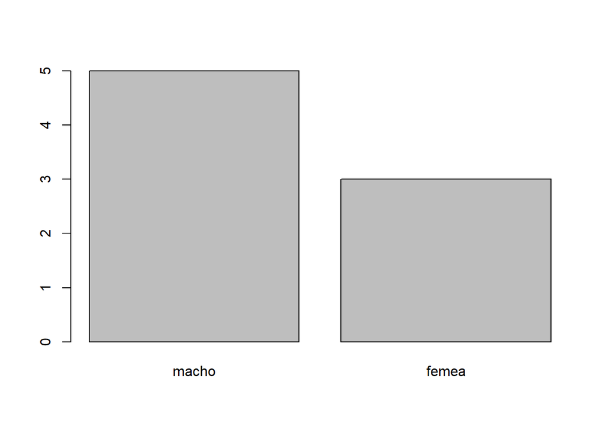

```r
# Resumir os dados do fator sexo através de um gráfico
plot(sexo_fator)
```

O código abaixo mostra como atribuir rótulos ao níveis do fatores:

```r
sexo_fator <- factor(sexo, levels = c("macho", "femea"),
                     labels = c("M", "F"))

str(sexo_fator)
```

```
##  Factor w/ 2 levels "M","F": 1 2 2 1 1 1 2 1
```

```r
levels(sexo_fator)
```

```
## [1] "M" "F"
```

```r
sexo_fator
```

```
## [1] M F F M M M F M
## Levels: M F
```

## 15.1 Converter colunas de uma data frame para `factor`

### 15.1.1 Fatores em Inventário Florestal

```r
# Lê uma planilha csv com dados de inventário florestal
inventario <- read.csv2('./data/UMF_4_UPA_4F_SINAFLOR_v03.csv',
                encoding = 'latin1')
```

```r
# Converter a coluna "QF" (qualidade do fuste) para fatores
inventario$QF <- factor(inventario$QF,
                        levels = c(1, 2, 3),
                        ordered = TRUE)
```

```r
# Resumo da coluna QF
summary(inventario$QF)
```

```
##     1     2     3
## 13761  4403   424
```

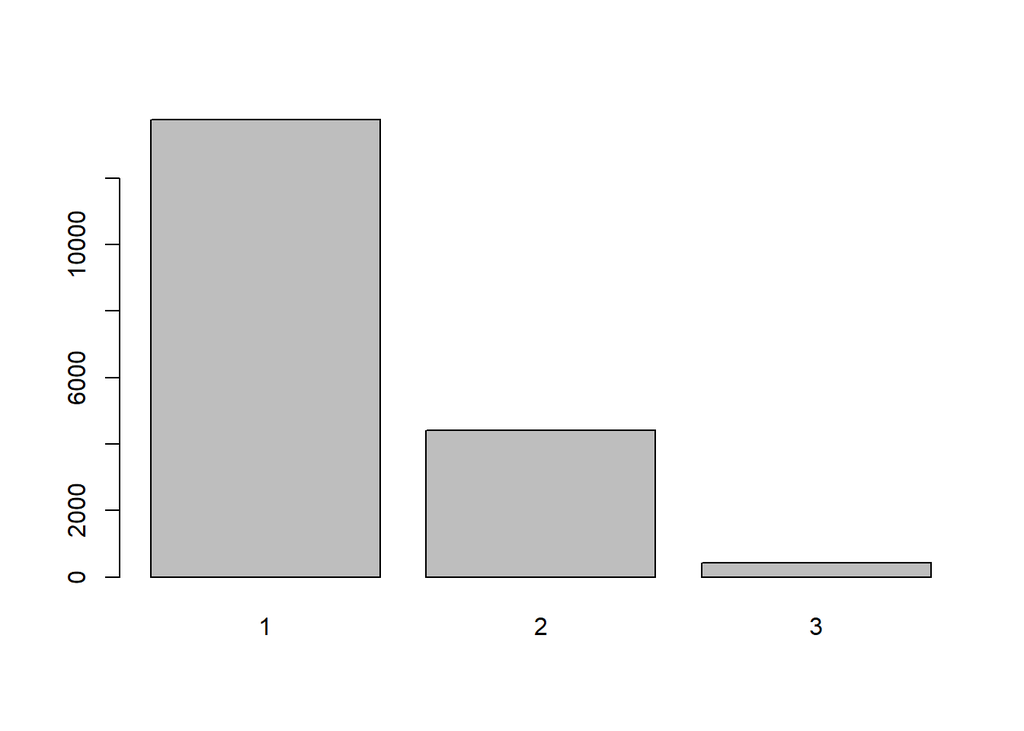

```r
# Visualização gráfica dos fatores
plot(inventario$QF)
```

## 15.2 Atribuir Rótulos ao Fator

Agora iremos atribuir rótulos ao nosso fator, os rótulos serão: Fuste 1, Fuste 2 e Fuste 3.

```r
# Converter a coluna "QF" (qualidade do fuste) para fatores e atribuir rótulos
inventario$QF <- factor(
    inventario$QF,
    levels = c(1, 2, 3),
    label = c('Fuste 1', 'Fuste 2', 'Fuste 3'),
    ordered = TRUE
)
```

```r
# Resumo da coluna QF
summary(inventario$QF)
```

```
## Fuste 1 Fuste 2 Fuste 3
##   13761    4403     424
```

```r
# Mostrar os dados com a inserção de rótulos aos fatores
head(inventario)
```

```
##   N_arv UPA UT     Nome_Cientifico Nome_Popular DAP_cm Alt    Categoria      QF
## 1 10001   6  1 Parkia gigantocarpa   Fava-atanã 114.59  19 Remanescente Fuste 1
## 2 10002   6  1  Bagassa guianensis     Tatajuba  67.48  17 Remanescente Fuste 1
## 3 10003   6  1       Castilla ulei       Caucho  52.52  11     Explorar Fuste 1
## 4 10004   6  1       Castilla ulei       Caucho  40.74  13 Remanescente Fuste 1
## 5 10005   6  1     Vochysia maxima      Quaruba  47.75  15 Remanescente Fuste 2
## 6 10006   6  1    Copaifera duckei      Copaíba  43.93  18 Remanescente Fuste 1
##       Vol      g       lat       lon
## 1 12.4891 1.0313 -5.907904 -54.96910
## 2  4.3893 0.3577 -5.907938 -54.96912
## 3  1.8263 0.2166 -5.907999 -54.96991
## 4  1.1068 0.1304 -5.906353 -54.96999
## 5  1.8325 0.1790 -5.906086 -54.97024
## 6  1.7038 0.1515 -5.905871 -54.97024
```

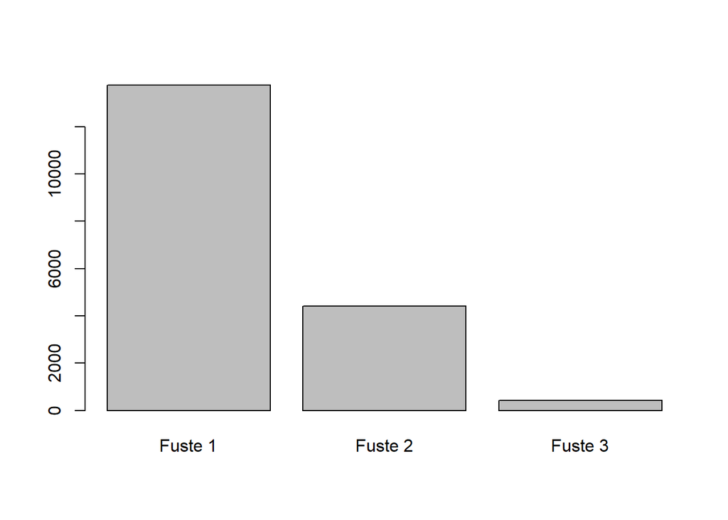

```r
# Visualização gráfica dos fatores
plot(inventario$QF)
```

## 15.3 Fatores - Lista Espécies Fauna Ameaçada de Extinção

```r
# Leitura dos dados
fauna <- read.csv2('./data/DF_port_MMA_300-2022_fauna.csv')

# Mostrar as seis primeiras linhas dos dados
head(fauna)
```

```
##   n port443 classe           ordem      familia       especie_subespecie
## 1 1       *   Aves Accipitriformes Accipitridae Amadonastur lacernulatus
## 2 2       *   Aves Accipitriformes Accipitridae          Circus cinereus
## 3 3       *   Aves Accipitriformes Accipitridae           Harpia harpyja
## 4 4       *   Aves Accipitriformes Accipitridae         Leptodon forbesi
## 5 5       *   Aves Accipitriformes Accipitridae      Morphnus guianensis
## 6 6       *   Aves Accipitriformes Accipitridae      Urubitinga coronata
##   categoria
## 1        VU
## 2        VU
## 3        VU
## 4        EN
## 5        VU
## 6        EN
```

```r
# Valores únicos para categoria de ameaça
unique(fauna$categoria)
```

```
## [1] "VU"       "EN"       "CR"       "CR (PEX)" "EX"       "RE"       "EW"
```

```r
# Resumo da coluna categoria
summary(fauna$categoria)
```

```
##    Length     Class      Mode
##      1266 character character
```

```r
# Converter os dados da coluna categoria para fatores
fauna$categoria <- factor(
    fauna$categoria,
    levels = c('VU', 'EN', 'CR', 'CR (PEX)', 'EX', 'RE', 'EW'),
    ordered = TRUE
)
```

```r
# Resumo da coluna categoria
summary(fauna$categoria)
```

```
##       VU       EN       CR CR (PEX)       EX       RE       EW
##      470      425      325       36        6        3        1
```

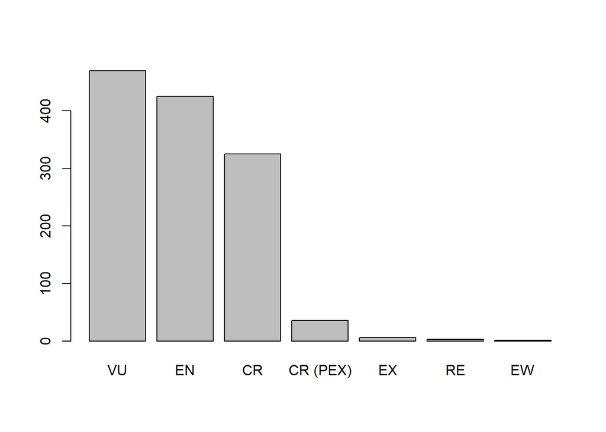

```r
# Visualização Gráfica dos Fatores
plot(fauna$categoria)
```

# 16 Listas

Imagine que você precisa ir ao supermercado, para se manter organizado e lembrar o que comprar, você provavelmente fará uma lista de compras. Pense no que pode haver nessa lista: Cereais, papel toalha, frutas, detergente… Vários tipos de coisas com formas e estruturas diferentes. Não importa o que seja, se você puder lembar, poderá colocá-los em sua lista. Assim como sua lista de compras, em R, existe um tipo de superestrutura de dados, também chamada de Lista, que permite agrupar outras estruturas de dados em, digamos, uma lista.

Para criar uma lista é simples, basta usar a função **list( )** e passar todas as estruturas de dados que você deseja dentro de sua lista.

Agora iremos criar a seguinte lista em R:

- farinha de trigo
- farinha de mandioca
- farinha de milho
- creme dental
- papel higiênico
- sabonete
- água sanitária
- detergente
- carne
- frango
- peixe
- cerveja
- sonrisal
- eparema

```r
lista <- list(c('farinha de trigo', 'farinha de mandioca', 'farinha de milho'),
              c('creme dental', 'papel higiênico', 'sabonete'),
              c('água sanitária', 'detergente'),
              c('carne', 'frango', 'peixe'),
              c('cerveja', 'sonrisal', 'eparema'))

print(lista)
```

```
## [[1]]
## [1] "farinha de trigo"    "farinha de mandioca" "farinha de milho"
##
## [[2]]
## [1] "creme dental"    "papel higiênico" "sabonete"
##
## [[3]]
## [1] "água sanitária" "detergente"
##
## [[4]]
## [1] "carne"  "frango" "peixe"
##
## [[5]]
## [1] "cerveja"  "sonrisal" "eparema"
```

## 16.1 Acessando elementos em uma lista

```r
# Selecionar todos os valores do primeiro ítem da lista
print(lista[[1]])
```

```
## [1] "farinha de trigo"    "farinha de mandioca" "farinha de milho"
```

```r
# Todos os elementos do terceiro vetor da lista
print(lista[[3]])
```

```
## [1] "água sanitária" "detergente"
```

```r
# Primeiro valor do primeiro da lista
print(lista[[1]][[1]])
```

```
## [1] "farinha de trigo"
```

```r
# Quarto e Quinto ítens da lista
nao_esquecer <- lista[c(4, 5)]
print(nao_esquecer)
```

```
## [[1]]
## [1] "carne"  "frango" "peixe"
##
## [[2]]
## [1] "cerveja"  "sonrisal" "eparema"
```

## 16.2 Nomear os elementos de uma lista

```r
# Definir nomes para os elementos da lista
names(lista) <- c('cereais', 'higiene', 'limpeza',
                  'proteína', 'birita')
```

```r
# No primeiro ítem da lista, filtrar apenas o primeiro sub-ítem
lista$cereais[[1]]
```

```
## [1] "farinha de trigo"
```

```r
# No segundo ítem da lista, filtar o primeiro sub-ítem
# No elemento flora, filtrar a primeira espécie
lista$higiene[[1]]
```

```
## [1] "creme dental"
```

## 16.3 Funções Aplicadas à lista

Praticamento todas as funções vistas nas aulas anteriores se aplicam à lista.

### 16.3.1 `str` e `summary`

```r
# Verificar a estrutua da lista
str(lista)
```

```
## List of 5
##  $ cereais : chr [1:3] "farinha de trigo" "farinha de mandioca" "farinha de milho"
##  $ higiene : chr [1:3] "creme dental" "papel higiênico" "sabonete"
##  $ limpeza : chr [1:2] "água sanitária" "detergente"
##  $ proteína: chr [1:3] "carne" "frango" "peixe"
##  $ birita  : chr [1:3] "cerveja" "sonrisal" "eparema"
```

```r
# Obter um resumo dos dados armazenados na lista
summary(lista)
```

```
##          Length Class  Mode
## cereais  3      -none- character
## higiene  3      -none- character
## limpeza  2      -none- character
## proteína 3      -none- character
## birita   3      -none- character
```

### 16.3.2 `lapply` e `sapply`

As funções `lapply` e `sapply` são uma variação da função `apply` para iterar sobre aos elementos de uma lista. Esta funções diferem somente na forma como os resultados são mostrados na tela. Para a função `lapply` a saída é na forma de lista, enquanto `sapply` apresenta uma saída vetorial.

```r
lista = list(x = c(1.55, 1.15, 1.71, 1.89, 1.65, 1.44),
             y = c(12.51, 9.89, 21.22, 22.11, 9.98))

print(lapply(lista, mean))
```

```
## $x
## [1] 1.565
##
## $y
## [1] 15.142
```

```r
# Média para cada elemento da lista
print(sapply(lista, mean))
```

```
##      x      y
##  1.565 15.142
```

```r
# Média apenas do elemento x da lista
print(mean(lista[[1]]))
```

```
## [1] 1.565
```

### 16.3.3 **`toString()`**

```r
print(toString(lista))
```

```
## [1] "c(1.55, 1.15, 1.71, 1.89, 1.65, 1.44), c(12.51, 9.89, 21.22, 22.11, 9.98)"
```

## 16.4 Converter Vetor para Lista

Há duas maneiras de converter um vetor para lista, uma delas é usar a função `list()` e passar como parâmetro o nome do vetor, a outra forma é usar a função `as.list()`. A diferença entre essas essas função é que `list()` produzirá uma lista formada pelos várias elementos do vetor, ao passo que a função `as.list()` irá gerar uma lista para cada elemento do vetor, coforme demonstrado no código a seguir.

```r
# Definição do vetor "numeros"
numeros <- c(1:26)

# Definição do vetor "letas"
letras <- letters

lista <- list(numeros, toupper(letras))

print(lista)
```

```
## [[1]]
##  [1]  1  2  3  4  5  6  7  8  9 10 11 12 13 14 15 16 17 18 19 20 21 22 23 24 25
## [26] 26
##
## [[2]]
##  [1] "A" "B" "C" "D" "E" "F" "G" "H" "I" "J" "K" "L" "M" "N" "O" "P" "Q" "R" "S"
## [20] "T" "U" "V" "W" "X" "Y" "Z"
```

### 16.4.1 `as.list`

```r
x = c(1.55, 1.15, 1.71, 1.89, 1.65, 1.44)

lista2 <- as.list(x)

print(head(lista2))
```

```
## [[1]]
## [1] 1.55
##
## [[2]]
## [1] 1.15
##
## [[3]]
## [1] 1.71
##
## [[4]]
## [1] 1.89
##
## [[5]]
## [1] 1.65
##
## [[6]]
## [1] 1.44
```

### 16.4.2 `list`

```r
# Convter o vetor "numeros" para lista usando a função list()
print(list(x))
```

```
## [[1]]
## [1] 1.55 1.15 1.71 1.89 1.65 1.44
```

Podemos aplicar função aos vetores no momento de criação da lista

```r
# Definição do vetor "numeros"
numeros <- c(1:26)

# Definição do vetor "letas"
letras <- letters

lista <- list(numeros, toupper(letras))

print(lista)
```

```
## [[1]]
##  [1]  1  2  3  4  5  6  7  8  9 10 11 12 13 14 15 16 17 18 19 20 21 22 23 24 25
## [26] 26
##
## [[2]]
##  [1] "A" "B" "C" "D" "E" "F" "G" "H" "I" "J" "K" "L" "M" "N" "O" "P" "Q" "R" "S"
## [20] "T" "U" "V" "W" "X" "Y" "Z"
```

```r
## Converter Dataframe para Lista

# definir o dataframe
df <- data.frame(a = c(1:5), b = c(6:10))

# Mostrar os dados do dataframe
df
```

```
##   a  b
## 1 1  6
## 2 2  7
## 3 3  8
## 4 4  9
## 5 5 10
```

```r
# converter o dataframe para lista utilizando a função list()
lista_df <- list(df)
print(lista_df)
```

```
## [[1]]
##   a  b
## 1 1  6
## 2 2  7
## 3 3  8
## 4 4  9
## 5 5 10
```

```r
# converter o dataframe para lista utilizando a função as.list()
lista_df <- as.list(df)
print(lista_df)
```

```
## $a
## [1] 1 2 3 4 5
##
## $b
## [1]  6  7  8  9 10
```

`as.list()` converte cada elemento do vetor em um elemento de lista, no caso de data frame cada coluna será uma elemento de lista.

## 16.5 Conhecendo a Versatilidade de uma lista

A lista a seguir contém todas as estruturas de dados que conhecemos neste curso, e formada pelo vetor de diâmetros de árvores (dap), uma matriz, um *array*, um *data frame* e uma lista. Observe que podemos inserir lista dentro de lista.

```r
li <- readRDS('./data/lista_exemplo.rds')

str(li)
```

```
## List of 5
##  $ Vetor     : num [1:18406] 114.6 67.5 52.5 40.7 47.8 ...
##   ..- attr(*, "Diâmetro de Árvores")= chr "Vetor de diâmetros"
##  $ Matriz    : int [1:3, 1:3] 1 2 3 4 5 6 7 8 9
##   ..- attr(*, "Observação")= chr "Exemplo de Matriz criada no curso"
##  $ Array     : int [1:3, 1:3, 1:2] 1 2 3 4 5 6 7 8 9 10 ...
##   ..- attr(*, "Observação")= chr "Exemplo de Array criado no curso"
##  $ Data frame:'data.frame':  5 obs. of  3 variables:
##   ..$ id    : num [1:5] 1 2 3 4 5
##   ..$ nome  : chr [1:5] "Mezilaurus itauba" "Apuleia leiocarpa" "Cedrela odorata" "Amburana acreana" ...
##   ..$ volume: num [1:5] 3.25 6.51 7.45 8.81 4.35
##   ..- attr(*, "Observação")= chr "Primeiro data frame criado no curso"
##  $ Lista     :List of 5
##   ..$ cereais : chr [1:3] "farinha de trigo" "farinha de mandioca" "farinha de milho"
##   ..$ higiene : chr [1:3] "creme dental" "papel higiênico" "sabonete"
##   ..$ limpeza : chr [1:2] "água sanitária" "detergente"
##   ..$ proteína: chr [1:3] "carne" "frango" "peixe"
##   ..$ birita  : chr [1:3] "cerveja" "sonrisal" "eparema"
##   ..- attr(*, "Observação")= chr "Primeira lista criado no curso"
```

### 16.5.1 Mostrar o Vetor Presente na lista

```r
head(li$Vetor)
```

```
## [1] 114.59  67.48  52.52  40.74  47.75  43.93
```

### 16.5.2 Extraindo a Matriz Presente na Lista

```r
li$Matriz
```

```
##      [,1] [,2] [,3]
## [1,]    1    4    7
## [2,]    2    5    8
## [3,]    3    6    9
## attr(,"Observação")
## [1] "Exemplo de Matriz criada no curso"
```

### 16.5.3 Extraindo a Array Presente na Lista

```r
li$Array
```

```
## , , 1
##
##      [,1] [,2] [,3]
## [1,]    1    4    7
## [2,]    2    5    8
## [3,]    3    6    9
##
## , , 2
##
##      [,1] [,2] [,3]
## [1,]   10   13   16
## [2,]   11   14   17
## [3,]   12   15   18
##
## attr(,"Observação")
## [1] "Exemplo de Array criado no curso"
```

### 16.5.4 Extraindo o Data Frame Presente na Lista

```r
li$`Data frame`
```

```
##   id                  nome volume
## 1  1     Mezilaurus itauba   3.25
## 2  2     Apuleia leiocarpa   6.51
## 3  3       Cedrela odorata   7.45
## 4  4      Amburana acreana   8.81
## 5  5 Hymenolobium excelsum   4.35
```

### 16.5.5 Extraindo a Lista Presente na Lista

```r
li$Lista
```

```
## $cereais
## [1] "farinha de trigo"    "farinha de mandioca" "farinha de milho"
##
## $higiene
## [1] "creme dental"    "papel higiênico" "sabonete"
##
## $limpeza
## [1] "água sanitária" "detergente"
##
## $proteína
## [1] "carne"  "frango" "peixe"
##
## $birita
## [1] "cerveja"  "sonrisal" "eparema"
##
## attr(,"Observação")
## [1] "Primeira lista criado no curso"
```

# 17 Aplicação do uso de lista em R

A seguir conheceremos uma lista gerada através de *[webscraping](https://www.in.gov.br/en/web/dou/-/portaria-gm/mma-n-300-de-13-de-dezembro-de-2022-450425464)* na página da Impresa Nacional, utilizando o pacote R Rvest. O objetivo foi extrair os dados das espécies da flora e fauna ameaçadas de extinção.

```r
# carregar a lista das espécies da fauna
lista_fauna <- readRDS('./data/lista_classes_fauna_ameacada.rds')

# Resumir os dados da lista
str(lista_fauna)
```

```
## List of 28
##  $ Actinopterygii:'data.frame':  329 obs. of  7 variables:
##   ..$ n                 : int [1:329] 129 191 192 193 194 195 196 197 198 199 ...
##   ..$ port443           : chr [1:329] "*" "*" "*" "*" ...
##   ..$ classe            : chr [1:329] "Actinopterygii" "Actinopterygii" "Actinopterygii" "Actinopterygii" ...
##   ..$ ordem             : chr [1:329] "Atheriniformes" "Characiformes" "Characiformes" "Characiformes" ...
##   ..$ familia           : chr [1:329] "Atherinopsidae" "Anostomidae" "Anostomidae" "Anostomidae" ...
##   ..$ especie_subespecie: chr [1:329] "Odontesthes bicudo" "Hypomasticus thayeri" "Leporinus guttatus" "Leporinus pitingai" ...
##   ..$ categoria         : chr [1:329] "EN" "VU" "VU" "CR" ...
##  $ Amphibia      :'data.frame':  59 obs. of  7 variables:
##   ..$ n                 : int [1:59] 33 34 37 38 39 40 41 42 43 44 ...
##   ..$ port443           : chr [1:59] "" "*" "" "*" ...
##   ..$ classe            : chr [1:59] "Amphibia" "Amphibia" "Amphibia" "Amphibia" ...
##   ..$ ordem             : chr [1:59] "Anura" "Anura" "Anura" "Anura" ...
##   ..$ familia           : chr [1:59] "Hylidae" "Phyllomedusidae" "Brachycephalidae" "Brachycephalidae" ...
##   ..$ especie_subespecie: chr [1:59] "Boana cymbalum" "Phrynomedusa fimbriata" "Brachycephalus mirissimus" "Brachycephalus pernix" ...
##   ..$ categoria         : chr [1:59] "EX" "EX" "VU" "CR" ...
##  $ Anthozoa      :'data.frame':  3 obs. of  7 variables:
##   ..$ n                 : int [1:3] 7 1065 1066
##   ..$ port443           : chr [1:3] "*" "*" "*"
##   ..$ classe            : chr [1:3] "Anthozoa" "Anthozoa" "Anthozoa"
##   ..$ ordem             : chr [1:3] "Actiniaria" "Scleractinia" "Scleractinia"
##   ..$ familia           : chr [1:3] "Actiniidae" "Mussidae" "Mussidae"
##   ..$ especie_subespecie: chr [1:3] "Condylactis gigantea" "Mussismilia braziliensis" "Mussismilia harttii"
##   ..$ categoria         : chr [1:3] "EN" "VU" "EN"
##  $ Arachnida     :'data.frame':  69 obs. of  7 variables:
##   ..$ n                 : int [1:69] 8 9 10 11 12 13 14 15 16 105 ...
##   ..$ port443           : chr [1:69] "*" "*" "" "*" ...
##   ..$ classe            : chr [1:69] "Arachnida" "Arachnida" "Arachnida" "Arachnida" ...
##   ..$ ordem             : chr [1:69] "Amblypygi" "Amblypygi" "Amblypygi" "Amblypygi" ...
##   ..$ familia           : chr [1:69] "Charinidae" "Charinidae" "Charinidae" "Charinidae" ...
##   ..$ especie_subespecie: chr [1:69] "Charinus acaraje" "Charinus asturius" "Charinus caatingae" "Charinus eleonorae" ...
##   ..$ categoria         : chr [1:69] "VU" "EN" "CR" "EN" ...
##  $ Asteroidea    :'data.frame':  7 obs. of  7 variables:
##   ..$ n                 : int [1:7] 499 845 846 847 848 1277 1278
##   ..$ port443           : chr [1:7] "*" "*" "*" "*" ...
##   ..$ classe            : chr [1:7] "Asteroidea" "Asteroidea" "Asteroidea" "Asteroidea" ...
##   ..$ ordem             : chr [1:7] "Forcipulatida" "Paxillosida" "Paxillosida" "Paxillosida" ...
##   ..$ familia           : chr [1:7] "Asteriidae" "Astropectinidae" "Astropectinidae" "Astropectinidae" ...
##   ..$ especie_subespecie: chr [1:7] "Coscinasterias tenuispina" "Astropecten articulatus" "Astropecten brasiliensis" "Astropecten marginatus" ...
```

[output cut: 170 more lines]

```
##   ..$ n                 : int [1:6] 1268 1269 1270 1271 1272 1273
##   ..$ port443           : chr [1:6] "" "" "" "" ...
##   ..$ classe            : chr [1:6] "Turbellaria" "Turbellaria" "Turbellaria" "Turbellaria" ...
##   ..$ ordem             : chr [1:6] "Tricladida" "Tricladida" "Tricladida" "Tricladida" ...
##   ..$ familia           : chr [1:6] "Dimarcusidae" "Dugesiidae" "Dugesiidae" "Dugesiidae" ...
##   ..$ especie_subespecie: chr [1:6] "Hausera hauseri" "Girardia arenicola" "Girardia desiderensis" "Girardia multidiverticulata" ...
##   ..$ categoria         : chr [1:6] "VU" "CR" "CR" "CR" ...
##  $ Udeonychophora:'data.frame':  4 obs. of  7 variables:
##   ..$ n                 : int [1:4] 495 496 497 498
##   ..$ port443           : chr [1:4] "*" "*" "*" "*"
##   ..$ classe            : chr [1:4] "Udeonychophora" "Udeonychophora" "Udeonychophora" "Udeonychophora"
##   ..$ ordem             : chr [1:4] "Euonychophora" "Euonychophora" "Euonychophora" "Euonychophora"
##   ..$ familia           : chr [1:4] "Peripatidae" "Peripatidae" "Peripatidae" "Peripatidae"
##   ..$ especie_subespecie: chr [1:4] "Epiperipatus adenocryptus" "Epiperipatus diadenoproctus" "Epiperipatus ohausi" "Epiperipatus paurognostus"
##   ..$ categoria         : chr [1:4] "CR" "VU" "EN" "CR"
```

```r
#  Selecionar e mostrar a classe das aves
head(lista_fauna$Aves)
```

```
##   n port443 classe           ordem      familia       especie_subespecie
## 1 1       *   Aves Accipitriformes Accipitridae Amadonastur lacernulatus
## 2 2       *   Aves Accipitriformes Accipitridae          Circus cinereus
## 3 3       *   Aves Accipitriformes Accipitridae           Harpia harpyja
## 4 4       *   Aves Accipitriformes Accipitridae         Leptodon forbesi
## 5 5       *   Aves Accipitriformes Accipitridae      Morphnus guianensis
## 6 6       *   Aves Accipitriformes Accipitridae      Urubitinga coronata
##   categoria
## 1        VU
## 2        VU
## 3        VU
## 4        EN
## 5        VU
## 6        EN
```

```r
tail(lista_fauna$Aves)
```

```
##         n port443 classe         ordem    familia     especie_subespecie
## 1231 1247       *   Aves    Suliformes    Sulidae              Sula sula
## 1247 1263       *   Aves  Tinamiformes  Tinamidae    Crypturellus zabele
## 1248 1264       *   Aves  Tinamiformes  Tinamidae          Nothura minor
## 1249 1265       *   Aves  Tinamiformes  Tinamidae        Taoniscus nanus
## 1250 1266       *   Aves  Tinamiformes  Tinamidae            Tinamus tao
## 1258 1274       *   Aves Trogoniformes Trogonidae Trogon collaris eytoni
##      categoria
## 1231        EN
## 1247        VU
## 1248        EN
## 1249        EN
## 1250        VU
## 1258        EN
```